# Projeto Integrador - Modelagem

Andre Giusti Dambry, Flavio Barbosa Shirahige, Michel Maurice Conjaud Neto e Tiago Evangelista Pardo

2023-09-13

## Etapa de Modelagem - Introdução

O objetivo dessa parte do Projeto Integrador é desenvolver um modelo previtivo para indicar se uma empresa irá falir em até dois anos a partir da avaliação de quatro classes de modelos: regressão logística, RIDGE/LASSO, floresta aleatória e Boosting. O pipeline de pré-processamento dos dados foi feito em Python. Nessa etapa de pré-processamento, foi criada a variável chamada will_close, que é a variável resposta desse processo de modelagem. Nela, o valor “1” significa que a empresa fechará em até 2 anos e ZERO (0) que a empresa não fechou nesse mesmo período de dois anos após 2012 (ano de referência para a modelagem).

Além dos modelos listados acima, serão utilizadas outras abordagens, como implementar o método de seleção de subconjuntos para as variáveis preditoras (stepwise) e testar o desempenho para modelagem por porte da empresa (pequena, média e grande), a ser feito de forma separada.

Para avaliar o desempenho de cada um dos modelos de classificação estimados, será utilizado a área sob a curva ROC (AUC), que mede a probabilidade de uma observação de evento ocorrer (no caso, se a empresa irá fechar) ter uma probabilidade maior do que uma observação do grupo de referência. Isto é, qual é o percentual de classificação correta do modelo em questão. Logo, um valor de AUC de um dado modelo igual 1 indica um desempenho de 100% na classificação e um valor de 0,5 significa que o modelo não é capaz de classificar de forma melhor do que uma escolha num processo aleatório.

O primeiro passo é importar os dados. Serão removidos os ID das empresas (comp_id), pois essas informações não serão utilizados na modelagem:

```r
dados <- read_csv("C:/Users/Flavio/Dropbox/My PC (LAPTOP-FVTATBSD)/Documents/Pós Insper Data Science/Projeto Integrador AEM I e CCD/df.csv", show_col_types = FALSE) %>%
  dplyr::select(-comp_id)
```

A próxima etapa é verificar se os dados foram migrados corretamente.

```r
skim(dados)
```

Data summary

| Name | dados |
| --- | --- |
| Number of rows | 21045 |
| Number of columns | 25 |
| _______________________ |  |
| Column type frequency: |  |
| character | 2 |
| numeric | 23 |
| ________________________ |  |
| Group variables | None |

**Variable type: character**

| skim_variable | n_missing | complete_rate | min | max | empty | n_unique | whitespace |
| --- | --- | --- | --- | --- | --- | --- | --- |
| region_m | 0 | 1 | 4 | 7 | 0 | 3 | 0 |
| comp_size | 0 | 1 | 5 | 7 | 0 | 3 | 0 |

**Variable type: numeric**

| skim_variable | n_missing | complete_rate | mean | sd | p0 | p25 | p50 | p75 | p100 | hist |
| --- | --- | --- | --- | --- | --- | --- | --- | --- | --- | --- |
| amort | 0 | 1 | 16451.89 | 176911.03 | -14896.30 | 0.00 | 488.89 | 2937.04 | 15921181.00 | ▇▁▁▁▁ |
| curr_assets | 0 | 1 | 195797.70 | 1850563.21 | -34600.00 | 1851.85 | 7970.37 | 31181.48 | 91489976.00 | ▇▁▁▁▁ |
| curr_liab | 0 | 1 | 175180.31 | 2812845.05 | -8759.26 | 1944.44 | 10829.63 | 40118.52 | 326405120.00 | ▇▁▁▁▁ |
| extra_exp | 0 | 1 | 1956.30 | 122313.58 | -1418.52 | 0.00 | 0.00 | 0.00 | 17041718.00 | ▇▁▁▁▁ |
| extra_inc | 0 | 1 | 2888.42 | 124608.73 | -7.41 | 0.00 | 0.00 | 0.00 | 17092322.00 | ▇▁▁▁▁ |
| extra_profit_loss | 0 | 1 | 931.96 | 41562.69 | -2211577.75 | 0.00 | 0.00 | 0.00 | 3253703.75 | ▁▁▇▁▁ |
| fixed_assets | 0 | 1 | 281762.29 | 6255207.51 | 0.00 | 0.00 | 2348.15 | 28433.33 | 686351872.00 | ▇▁▁▁▁ |
| inc_bef_tax | 0 | 1 | 19970.66 | 666956.74 | -13973230.00 | -4807.41 | -74.07 | 2485.19 | 77992592.00 | ▇▁▁▁▁ |
| intang_assets | 0 | 1 | 13727.75 | 1107405.46 | -29.63 | 0.00 | 0.00 | 0.00 | 159444448.00 | ▇▁▁▁▁ |
| inventories | 0 | 1 | 58179.07 | 666267.74 | -2607.41 | 0.00 | 240.74 | 4855.56 | 30963558.00 | ▇▁▁▁▁ |
| liq_assets | 0 | 1 | 37482.21 | 644036.58 | -130333.34 | 288.89 | 1562.96 | 6837.04 | 79224256.00 | ▇▁▁▁▁ |
| material_exp | 0 | 1 | 317587.66 | 2686433.75 | -273433.34 | 2392.59 | 18507.41 | 72274.07 | 96001928.00 | ▇▁▁▁▁ |
| personnel_exp | 0 | 1 | 84200.94 | 685157.63 | -147066.67 | 285.19 | 7218.52 | 22977.78 | 45855412.00 | ▇▁▁▁▁ |
| profit_loss_year | 0 | 1 | 5316.06 | 255193.46 | -13973230.00 | -4811.11 | -74.07 | 1574.07 | 17001730.00 | ▁▁▇▁▁ |
| sales_x | 0 | 1 | 249859.19 | 780327.20 | 1003.70 | 16566.67 | 46888.89 | 146500.00 | 9997007.00 | ▇▁▁▁▁ |
| share_eq | 0 | 1 | 214867.90 | 5351237.11 | -39509640.00 | -7433.33 | 1959.26 | 21240.74 | 692925952.00 | ▇▁▁▁▁ |
| subscribed_cap | 0 | 1 | 76731.98 | 1500646.10 | -303.70 | 1851.85 | 1851.85 | 11111.11 | 159444448.00 | ▇▁▁▁▁ |
| tang_assets | 0 | 1 | 208393.40 | 3561213.51 | 0.00 | 0.00 | 2000.00 | 25574.07 | 451100736.00 | ▇▁▁▁▁ |
| urban_m | 0 | 1 | 2.08 | 0.85 | 1.00 | 1.00 | 2.00 | 3.00 | 3.00 | ▆▁▆▁▇ |
| labor_avg | 0 | 1 | 0.90 | 3.85 | 0.08 | 0.12 | 0.33 | 0.90 | 151.33 | ▇▁▁▁▁ |
| will_close | 0 | 1 | 0.03 | 0.16 | 0.00 | 0.00 | 0.00 | 0.00 | 1.00 | ▇▁▁▁▁ |
| curr_idx_liq | 0 | 1 | 624.89 | 16569.16 | -1366.67 | 0.27 | 1.11 | 3.59 | 1851851.88 | ▇▁▁▁▁ |
| comp_age | 0 | 1 | 8.47 | 7.01 | -4.00 | 2.00 | 7.00 | 14.00 | 63.00 | ▇▆▁▁▁ |

Como há variáveis categóricas, vamos transformá-las em fator para a modelagem:

```r
dados <- dados %>%
  mutate_if(is.character, ~as.factor(.x))
```

## Análise dos Modelos

Nesse passo, vamos construir os modelos para predizer a variável resposta will_close (se a empresa irá falir em até dois anos), a saber:

- Regressão Logísitica
- Rigde
- LASSO
- Floresta Aleatória
- Boosting

A etapa seguinte é criar os datasets de treinamento e teste, onde 80% do dataset será de treinamento:

```r
set.seed(123)

idx <- sample(nrow(dados), size = .80 * nrow(dados), replace = FALSE)

treino <- dados[idx,]
teste  <- dados[-idx,]
```

### Regressão Logística

O primeiro modelo a ser estimado é o de regressão logística:

```r
log <- glm(will_close ~ ., data = treino, family = 'binomial')
```

```
## Warning: glm.fit: probabilidades ajustadas numericamente 0 ou 1 ocorreu
```

```r
summary(log)
```

```
##
## Call:
## glm(formula = will_close ~ ., family = "binomial", data = treino)
##
## Coefficients:
##                     Estimate Std. Error z value Pr(>|z|)
## (Intercept)       -4.691e+00  2.028e-01 -23.128   <2e-16 ***
## amort             -2.999e-07  1.200e-06  -0.250   0.8026
## curr_assets       -1.132e-08  2.284e-07  -0.050   0.9605
## curr_liab         -7.942e-08  1.925e-07  -0.413   0.6799
## extra_exp         -2.804e-04  2.779e-04  -1.009   0.3130
## extra_inc          2.759e-04  2.778e-04   0.993   0.3206
## extra_profit_loss -2.766e-04  2.778e-04  -0.996   0.3194
## fixed_assets       9.172e-09  1.910e-07   0.048   0.9617
## inc_bef_tax       -1.854e-09  7.161e-07  -0.003   0.9979
## intang_assets     -1.779e-08  1.937e-07  -0.092   0.9268
## inventories        3.720e-08  2.764e-07   0.135   0.8929
## liq_assets         1.708e-07  2.623e-07   0.651   0.5149
## material_exp       1.138e-08  5.403e-08   0.211   0.8332
## personnel_exp      6.732e-08  3.037e-07   0.222   0.8246
## profit_loss_year   2.843e-07  9.473e-07   0.300   0.7641
## sales_x            7.041e-08  8.586e-08   0.820   0.4122
## share_eq          -1.897e-08  1.447e-07  -0.131   0.8957
## subscribed_cap     1.096e-08  1.229e-07   0.089   0.9290
## tang_assets       -5.300e-08  1.911e-07  -0.277   0.7815
## urban_m            6.942e-02  6.514e-02   1.066   0.2866
## region_mEast      -2.267e-01  1.328e-01  -1.708   0.0877 .
## region_mWest      -7.291e-02  1.508e-01  -0.483   0.6289
## labor_avg         -4.958e-03  3.997e-02  -0.124   0.9013
## curr_idx_liq      -2.324e-06  7.320e-06  -0.318   0.7508
## comp_age           9.027e-03  6.975e-03   1.294   0.1956
## comp_sizeMédia     1.193e-01  2.296e-01   0.520   0.6033
## comp_sizePequena   1.318e+00  1.573e-01   8.378   <2e-16 ***
## ---
## Signif. codes:  0 '***' 0.001 '**' 0.01 '*' 0.05 '.' 0.1 ' ' 1
##
## (Dispersion parameter for binomial family taken to be 1)
##
##     Null deviance: 3951.9  on 16835  degrees of freedom
## Residual deviance: 3809.6  on 16809  degrees of freedom
## AIC: 3863.6
##
## Number of Fisher Scoring iterations: 9
```

A aplicação da função glm do R gerou o alerta (“warning”) a seguir: “Warning: glm.fit: probabilidades ajustadas numericamente 0 ou 1 ocorreu”. Esse alerta pode ser causado por outliers. Para tentar mitigar esse problema, vamos posteriormente estimar os mesmos modelos sem os outliers. Por ora, vamos continuar na estimativa e avaliação dos 5 modelos descritos acima.

Agora, vamos aplicar o modelo de previsão nos dados de teste para estimar as probabilidades:

```r
prob_log <- predict(log, newdata = teste, type = "response")
```

E armazenar em um tibble os resultados das probabilidades obtidas pela regressão logística e a respectiva classe observada:

```r
desempenho <- tibble(prob = prob_log,
                   classes = teste$will_close,
                   metodo = "logística")
```

Abaixo, foi plotado o gráfico com a importância de cada variável para esse modelo:

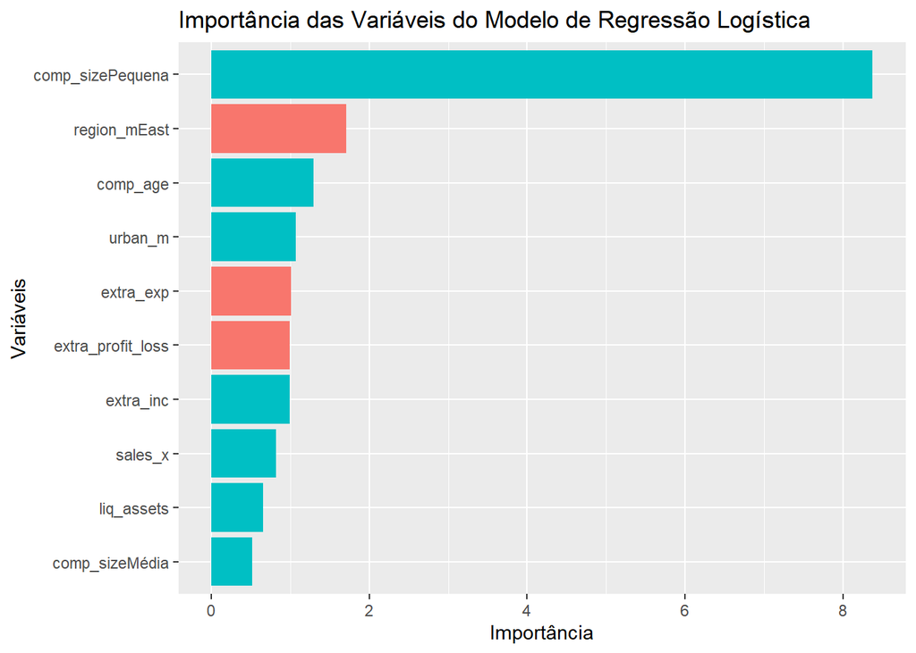

```r
vip(log, mapping = aes(fill = Sign)) + labs(title = "Importância das Variáveis do Modelo de Regressão Logística", x = "Variáveis", y = "Importância")
```

```r
dados_reduz <- subset(dados, select = -c(comp_size))
treino_reduz <- subset(treino, select = -c(comp_size))
teste_reduz <- subset(teste, select = -c(comp_size))
```

O primeiro modelo a ser estimado é o de regressão logística:

```r
log_reduz <- glm(will_close ~ ., data = treino_reduz, family = 'binomial')
```

```
## Warning: glm.fit: probabilidades ajustadas numericamente 0 ou 1 ocorreu
```

```r
summary(log_reduz)
```

```
##
## Call:
## glm(formula = will_close ~ ., family = "binomial", data = treino_reduz)
##
## Coefficients:
##                     Estimate Std. Error z value Pr(>|z|)
## (Intercept)       -3.754e+00  1.493e-01 -25.143  < 2e-16 ***
## amort             -3.445e-07  1.237e-06  -0.279  0.78055
## curr_assets       -1.680e-08  2.266e-07  -0.074  0.94089
## curr_liab         -7.065e-08  2.006e-07  -0.352  0.72473
## extra_exp         -3.187e-04  2.798e-04  -1.139  0.25473
## extra_inc          3.147e-04  2.798e-04   1.125  0.26061
## extra_profit_loss -3.155e-04  2.798e-04  -1.128  0.25940
## fixed_assets       1.997e-08  1.719e-07   0.116  0.90752
## inc_bef_tax       -4.457e-08  6.437e-07  -0.069  0.94480
## intang_assets     -2.926e-08  1.738e-07  -0.168  0.86627
## inventories        3.229e-08  2.626e-07   0.123  0.90215
## liq_assets         1.594e-07  2.540e-07   0.628  0.53030
## material_exp       1.400e-08  5.273e-08   0.265  0.79068
## personnel_exp      3.173e-08  2.985e-07   0.106  0.91535
## profit_loss_year   3.497e-07  8.501e-07   0.411  0.68080
## sales_x           -3.837e-07  1.346e-07  -2.851  0.00436 **
## share_eq          -1.248e-08  1.470e-07  -0.085  0.93235
## subscribed_cap     7.828e-09  1.198e-07   0.065  0.94789
## tang_assets       -7.168e-08  1.630e-07  -0.440  0.66007
## urban_m            7.818e-02  6.481e-02   1.206  0.22772
## region_mEast      -2.429e-01  1.322e-01  -1.838  0.06607 .
## region_mWest      -8.430e-02  1.502e-01  -0.561  0.57459
## labor_avg         -1.079e-03  3.904e-02  -0.028  0.97795
## curr_idx_liq      -2.832e-06  7.844e-06  -0.361  0.71803
## comp_age           9.931e-03  6.955e-03   1.428  0.15333
## ---
## Signif. codes:  0 '***' 0.001 '**' 0.01 '*' 0.05 '.' 0.1 ' ' 1
##
## (Dispersion parameter for binomial family taken to be 1)
##
##     Null deviance: 3951.9  on 16835  degrees of freedom
## Residual deviance: 3928.3  on 16811  degrees of freedom
## AIC: 3978.3
##
## Number of Fisher Scoring iterations: 9
```

A aplicação da função glm do R gerou o alerta (“warning”) a seguir: “Warning: glm.fit: probabilidades ajustadas numericamente 0 ou 1 ocorreu”. Esse alerta pode ser causado por outliers. Para tentar mitigar esse problema, vamos posteriormente estimar os mesmos modelos sem os outliers. Por ora, vamos continuar na estimativa e avaliação dos 5 modelos descritos acima.

Agora, vamos aplicar o modelo de previsão nos dados de teste para estimar as probabilidades:

```r
prob_log_reduz <- predict(log_reduz, newdata = teste_reduz, type = "response")
```

E armazenar em um tibble os resultados das probabilidades obtidas pela regressão logística e a respectiva classe observada:

```r
desempenho <- desempenho %>%
  bind_rows(tibble(prob = prob_log_reduz,
                   classes = teste_reduz$will_close,
                   metodo = "logística sem comp_size"))
```

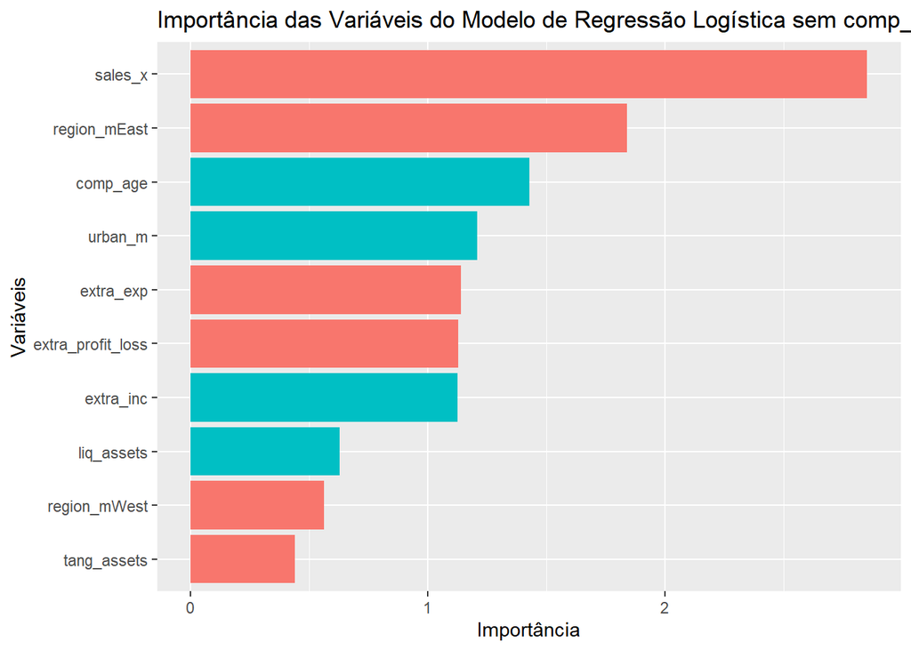

```r
vip(log_reduz, mapping = aes(fill = Sign)) +
  labs(title = "Importância das Variáveis do Modelo de Regressão Logística sem comp_size", x = "Variáveis", y = "Importância")
```

### Modelo Ridge

O próximo modelo a ser estimado é o Ridge. Primeiro, deverão ser preparadados os datasets de treinamento e teste para aplicação da função do pacote glmnet.

```r
X_treino <- model.matrix(will_close ~ ., dados)[idx,-1]
y_treino <- dados$will_close[idx]

X_teste <- model.matrix(will_close ~ ., dados)[-idx,-1]
y_teste <- dados$will_close[-idx]
```

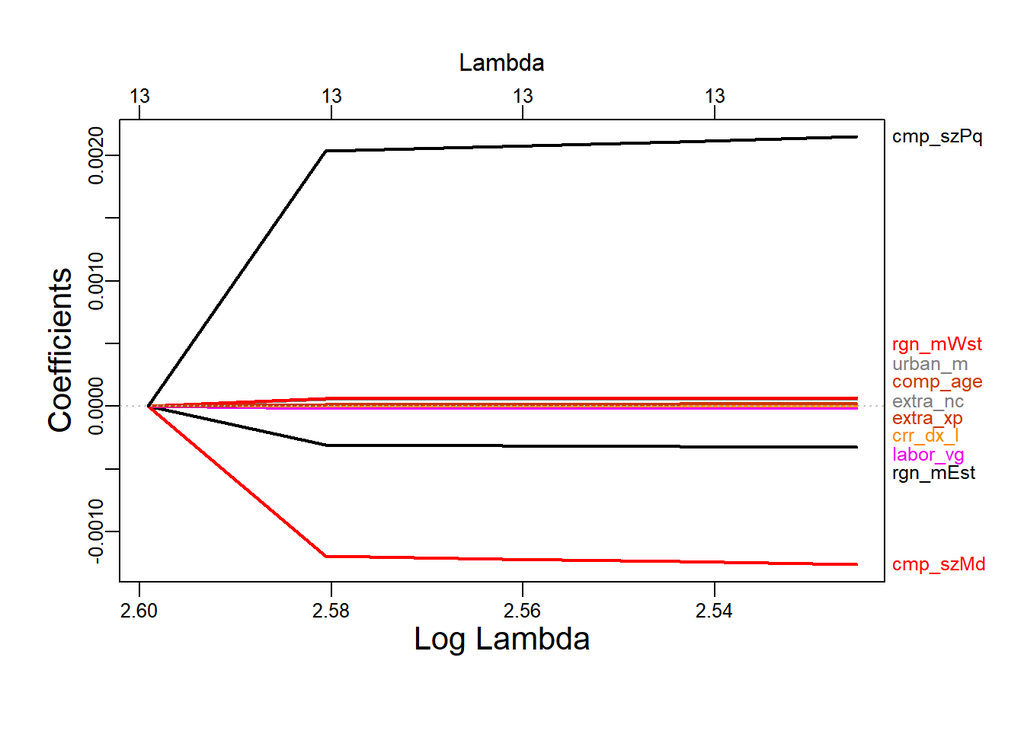

```r
ridge <- glmnet(X_treino, y_treino,  alpha = 0, nlambda = 500, family = "binomial")
plot_glmnet(ridge, lwd = 2, cex.lab = 1.3)
```

A seguir, vamos fazer a validação cruzada do modelo:

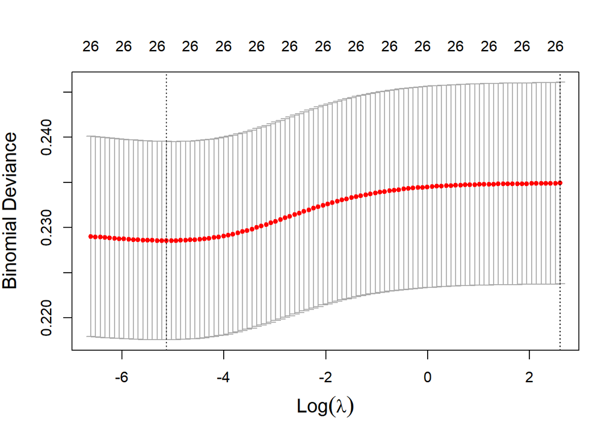

```r
cv_ridge <- cv.glmnet(X_treino, y_treino, alpha = 0, family = "binomial")
plot(cv_ridge, cex.lab = 1.3)
```

Vamos aplicar o modelo de previsão com base no melhor lambda (menor erro), estimando as probabilidades a partir da base de teste:

```r
prob_ridge <- predict(ridge, newx = X_teste, s = cv_ridge$lambda.min, type = "response")
```

E armazenar em um tibble os resultados das probabilidades obtidas pelo modelo Ridge e a respectiva classe observada:

```r
desempenho <- desempenho %>%
  bind_rows(tibble(prob = as.numeric(prob_ridge),
                   classes = y_teste,
                   metodo = "ridge"))
```

Abaixo, plotamos o gráfico com a importância de cada variável para esse modelo Rigde:

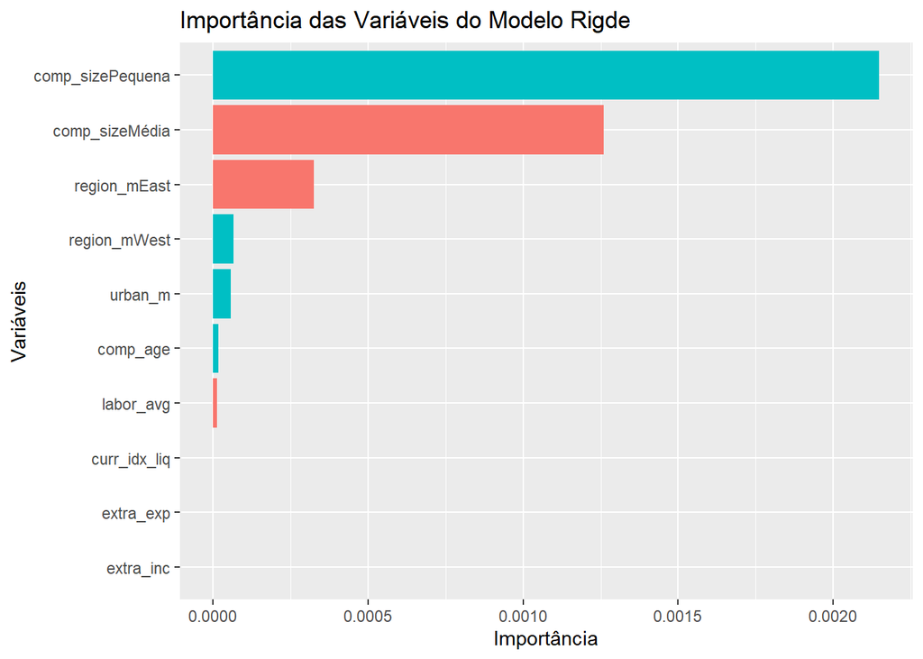

```r
vip(ridge, mapping = aes(fill = Sign)) + labs(title = "Importância das Variáveis do Modelo Rigde", x = "Variáveis", y = "Importância")
```

### Regressão LASSO

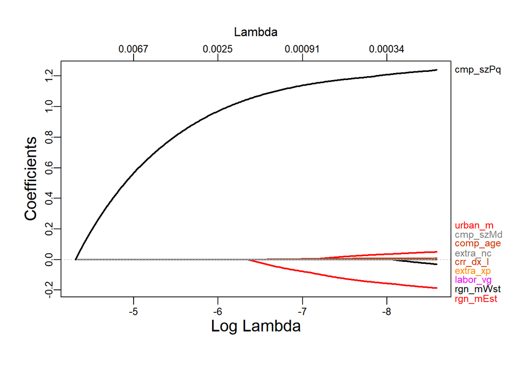

```r
lasso <- glmnet(X_treino, y_treino,  alpha = 1, nlambda = 500, family = "binomial")
plot_glmnet(lasso, lwd = 2, cex.lab = 1.3)
```

O próximo passo é fazer a validação cruzada do modelo:

```r
cv_lasso <- cv.glmnet(X_treino, y_treino, alpha = 1, family = "binomial")
```

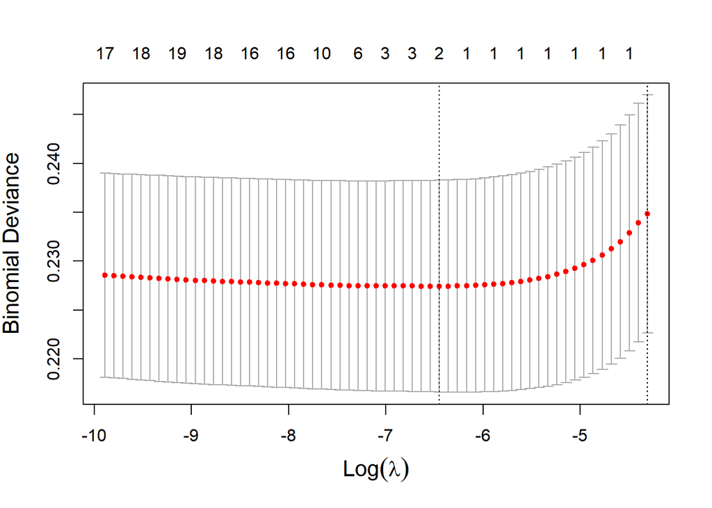

```r
plot(cv_lasso, cex.lab = 1.3)
```

Agora, será aplicado o modelo de previsão com base no melhor lambda (menor erro), estimando as probabilidades a partir da base de teste:

```r
prob_lasso <- predict(lasso, newx = X_teste, s = cv_lasso$lambda.min, type = "response")
```

E armazenado em um tibble os resultados das probabilidades obtidas pelo modelo Lasso e a respectiva classe observada:

```r
desempenho <- desempenho %>%
  bind_rows(tibble(prob = as.numeric(prob_lasso),
                   classes = y_teste,
                   metodo = "lasso"))
```

Abaixo, foi plotado o gráfico com a importância de cada variável para esse modelo:

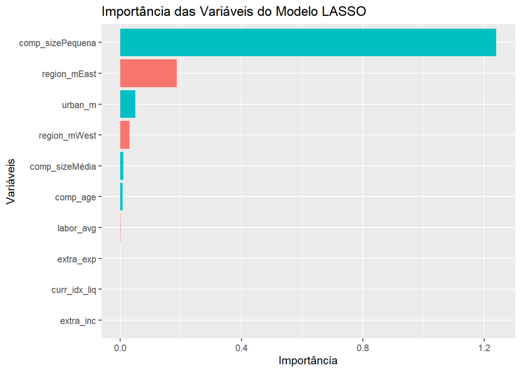

```r
vip(lasso, mapping = aes(fill = Sign)) + labs(title = "Importância das Variáveis do Modelo LASSO", x = "Variáveis", y = "Importância")
```

### Floresta Aleatória

O próximo modelo que será criado e testado é o de floresta aleatória com 500 árvores e com todas as variáveis:

```r
rf <- ranger(will_close ~ ., probability = TRUE, data = treino)
```

Para essa floresta aleatória com 500 árvores e com todas as variáveis, vamos fazer a previsão a partir dos dados de teste:

```r
prob_rf <- predict(rf, teste)$predictions[,2]
```

E armazenando em um tibble os resultados das probabilidades obtidas pelo modelo de floresta aleatória e a respectiva classe observada:

```r
desempenho <- desempenho %>%
  bind_rows(tibble(prob = prob_rf,
                   classes = teste$will_close,
                   metodo = "floresta aleatória"))
```

Abaixo, plotamos o gráfico com a importância de cada variável para esse modelo de floresta aleatória:

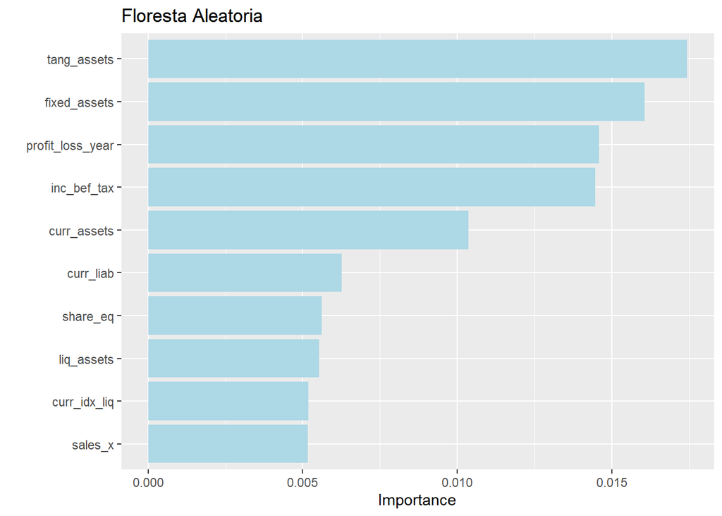

```r
vip(ranger(will_close ~ ., probability = TRUE, importance = "permutation", data = dados), aesthetics = list(fill = "lightblue")) + labs(title = "Floresta Aleatoria")
```

Agora, vamos iterar para testar o número de árvores de 1 a 500, bem como o número de variáveis por split, plotar o resultado dessa iteração:

```r
result_arvores <- crossing(mtry = c(2, 4, 8, 12, 16, 20, 23), #número de variáveis por split a ser testados
                       n_arvores = c(1:10, seq(10, 500, 10)))
itera <- function(mtry, n_arvores) {
  rf_itera <- ranger(will_close ~ ., probability = TRUE, num.trees = n_arvores, mtry = mtry, data = treino)
  return(rf_itera$prediction.error)
}
result_arvores <- result_arvores %>%
  mutate(erro = map2_dbl(mtry, n_arvores, itera))
head(result_arvores)
```

```
## # A tibble: 6 × 3
##    mtry n_arvores   erro
##   <dbl>     <dbl>  <dbl>
## 1     2         1 0.0388
## 2     2         2 0.0375
## 3     2         3 0.0349
## 4     2         4 0.0347
## 5     2         5 0.0337
## 6     2         6 0.0327
```

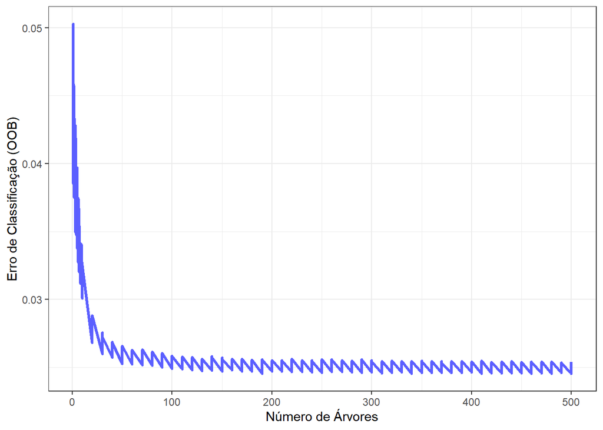

```r
result_arvores %>% ggplot(aes(n_arvores, erro)) +
 geom_line(color = "#5B5FFF", size = 1.2) +
 labs(x = "Número de Árvores", y = "Erro de Classificação (OOB)") +
 theme_bw()
```

A partir da iteração acima, vamos obter os dados da floresta ótima (número de árvores e número de variáveis por split) com o menor erro:

```r
floresta_otima <- result_arvores %>% as_tibble() %>% filter(erro== min(erro))#Obtendo dados da floresta ótima
mtry_otimo <- floresta_otima$mtry #numero de arvores para floresta otima
n_arvores_otimo <- floresta_otima$n_arvores # variaveis por split
```

E criar o modelo de floresta aleatória ótima:

```r
rf_otima <- ranger(will_close ~ ., probability = TRUE, num.trees = n_arvores_otimo,
                   mtry = mtry_otimo, data = treino)
```

Para essa floresta aleatória ótima, vamos fazer a previsão a partir dos dados de teste:

```r
prob_rf_otima <- predict(rf_otima, teste)$predictions[,2]
```

```r
desempenho <- desempenho %>%
  bind_rows(tibble(prob = prob_rf_otima,
                   classes = teste$will_close,
                   metodo = "floresta aleatória ótima"))
```

Abaixo, plotamos o gráfico com a importância de cada variável para esse modelo de floresta aleatória otimizada:

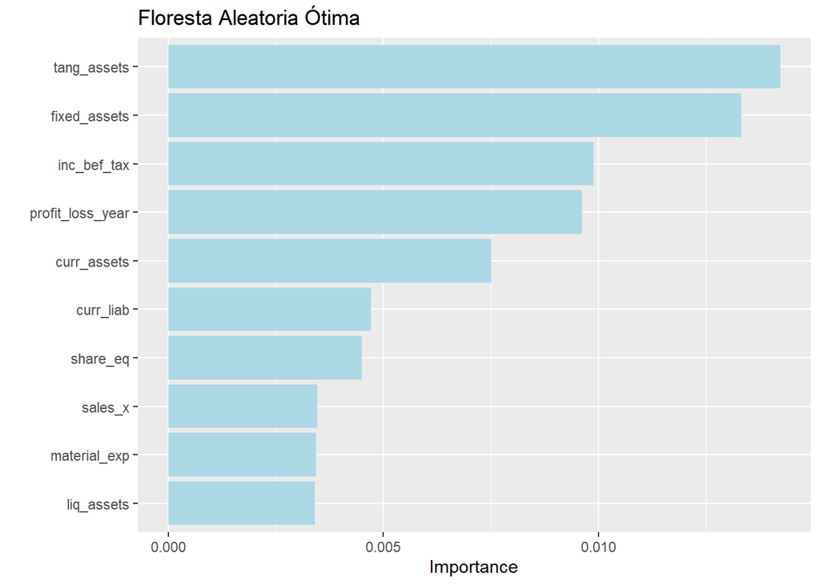

```r
vip(ranger(will_close ~ ., probability = TRUE, importance = "permutation", num.trees = n_arvores_otimo, mtry = mtry_otimo, data = treino),
    aesthetics = list(fill = "lightblue")) + labs(title = "Floresta Aleatoria Ótima")
```

### Boosting

O último modelo que será criado e testado nesse ciclo de modelagem é o Boosting com 500 árvores e taxa de aprendizagem 0,05:

```r
(fit_bst <- gbm(will_close ~ ., distribution = "bernoulli", n.trees = 500,
                interaction.depth = 4, shrinkage = 0.05, data = treino))
```

```
## gbm(formula = will_close ~ ., distribution = "bernoulli", data = treino,
##     n.trees = 500, interaction.depth = 4, shrinkage = 0.05)
## A gradient boosted model with bernoulli loss function.
## 500 iterations were performed.
## There were 24 predictors of which 24 had non-zero influence.
```

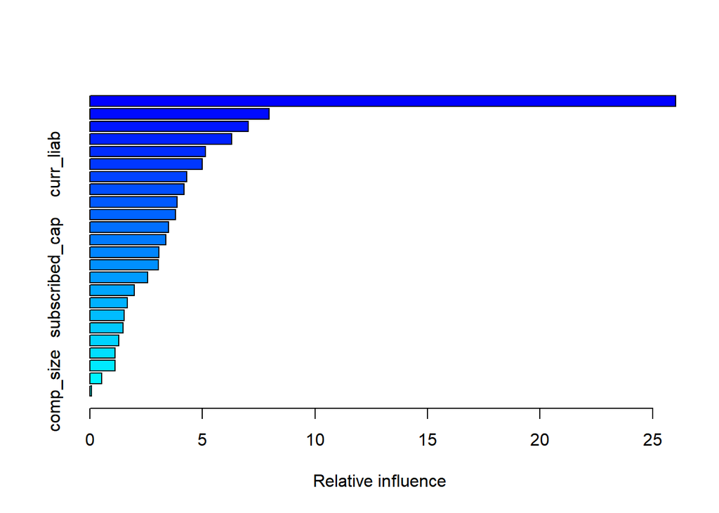

```
##                                 var     rel.inf
## sales_x                     sales_x 26.03025964
## liq_assets               liq_assets  7.96041647
## share_eq                   share_eq  7.03905450
## curr_idx_liq           curr_idx_liq  6.31121352
## inc_bef_tax             inc_bef_tax  5.14874630
## curr_liab                 curr_liab  4.98335272
## labor_avg                 labor_avg  4.31371051
## curr_assets             curr_assets  4.19096773
## inventories             inventories  3.88353943
## profit_loss_year   profit_loss_year  3.80979478
## personnel_exp         personnel_exp  3.50383069
## amort                         amort  3.38539464
## material_exp           material_exp  3.06212231
## comp_age                   comp_age  3.05297318
## subscribed_cap       subscribed_cap  2.57766983
## fixed_assets           fixed_assets  1.96839771
## extra_inc                 extra_inc  1.65663121
## extra_profit_loss extra_profit_loss  1.52348344
## tang_assets             tang_assets  1.48188253
## intang_assets         intang_assets  1.28542573
## extra_exp                 extra_exp  1.12314642
## urban_m                     urban_m  1.11491244
## region_m                   region_m  0.52937448
## comp_size                 comp_size  0.06369982
```

```r
summary(fit_bst)
```

O passo seguinte é fazer a validação cruzadas do modelo para obter o número de árvores ótimo:

```r
fit_cv <- gbm(will_close ~ ., data = treino, cv.folds = 5, n.trees = 500,
              interaction.depth = 4, distribution = "bernoulli", shrinkage = 0.05)

num_arv_boost <- gbm.perf(fit_cv, method = "cv") #obtendo a árvore ótima
```

[figure not shown]

Aplicando o modelo de previsão com base na melhor quantidade de árvores (menor erro) e estimando as probabilidades a partir da base de teste, temos:

```r
prob_gbm <- predict(fit_cv, teste, n.trees = num_arv_boost, type = "response")
```

```r
desempenho <- desempenho %>%
  bind_rows(tibble(prob = prob_gbm,
                   classes = teste$will_close,
                   metodo = "boosting"))
```

### Regressão logística com stepwise

Após estimar os cincos modelos acima, vamos verificar se a redução de variáveis para o modelo de regressão logística melhora o desempenho deste. Para tal, será utilizado o método stepwise. Assim, vamos selecionar primeiro as variáveis a serem utilizadas por meio do método stepwise:

```r
modelo_stepAIC <- stepAIC(log, direction = "both")
```

```
## Start:  AIC=3863.63
## will_close ~ amort + curr_assets + curr_liab + extra_exp + extra_inc +
##     extra_profit_loss + fixed_assets + inc_bef_tax + intang_assets +
##     inventories + liq_assets + material_exp + personnel_exp +
##     profit_loss_year + sales_x + share_eq + subscribed_cap +
##     tang_assets + urban_m + region_m + labor_avg + curr_idx_liq +
##     comp_age + comp_size
```

[output not shown]

```
##                     Df Deviance    AIC
## - inc_bef_tax        1   3809.6 3861.6
## - fixed_assets       1   3809.6 3861.6
## - curr_assets        1   3809.6 3861.6
## - subscribed_cap     1   3809.6 3861.6
## - intang_assets      1   3809.6 3861.6
## - labor_avg          1   3809.6 3861.6
## - share_eq           1   3809.6 3861.6
## - inventories        1   3809.7 3861.7
## - material_exp       1   3809.7 3861.7
## - personnel_exp      1   3809.7 3861.7
## - amort              1   3809.7 3861.7
## - tang_assets        1   3809.7 3861.7
## - profit_loss_year   1   3809.7 3861.7
## - curr_idx_liq       1   3809.8 3861.8
## - curr_liab          1   3809.8 3861.8
## - liq_assets         1   3810.1 3862.1
## - sales_x            1   3810.2 3862.2
## - extra_inc          1   3810.3 3862.3
## - extra_profit_loss  1   3810.3 3862.3
## - extra_exp          1   3810.4 3862.4
## - region_m           2   3812.6 3862.6
## - urban_m            1   3810.8 3862.8
## - comp_age           1   3811.3 3863.3
## <none>                   3809.6 3863.6
## - comp_size          2   3928.3 3978.3
```

```
##
## Step:  AIC=3861.63
## will_close ~ amort + curr_assets + curr_liab + extra_exp + extra_inc +
##     extra_profit_loss + fixed_assets + intang_assets + inventories +
##     liq_assets + material_exp + personnel_exp + profit_loss_year +
##     sales_x + share_eq + subscribed_cap + tang_assets + urban_m +
##     region_m + labor_avg + curr_idx_liq + comp_age + comp_size
```

[output not shown]

```
##                     Df Deviance    AIC
## - fixed_assets       1   3809.6 3859.6
## - curr_assets        1   3809.6 3859.6
## - subscribed_cap     1   3809.6 3859.6
## - intang_assets      1   3809.6 3859.6
## - labor_avg          1   3809.6 3859.6
## - share_eq           1   3809.6 3859.6
## - inventories        1   3809.7 3859.7
## - material_exp       1   3809.7 3859.7
## - personnel_exp      1   3809.7 3859.7
## - amort              1   3809.7 3859.7
## - tang_assets        1   3809.7 3859.7
## - curr_idx_liq       1   3809.8 3859.8
## - curr_liab          1   3809.8 3859.8
## - profit_loss_year   1   3810.0 3860.0
## - liq_assets         1   3810.1 3860.1
## - sales_x            1   3810.2 3860.2
## - extra_inc          1   3810.3 3860.3
## - extra_profit_loss  1   3810.3 3860.3
## - extra_exp          1   3810.4 3860.4
## - region_m           2   3812.6 3860.6
## - urban_m            1   3810.8 3860.8
## - comp_age           1   3811.3 3861.3
## <none>                   3809.6 3861.6
## + inc_bef_tax        1   3809.6 3863.6
## - comp_size          2   3928.3 3976.3
```

```
##
## Step:  AIC=3859.63
## will_close ~ amort + curr_assets + curr_liab + extra_exp + extra_inc +
##     extra_profit_loss + intang_assets + inventories + liq_assets +
##     material_exp + personnel_exp + profit_loss_year + sales_x +
##     share_eq + subscribed_cap + tang_assets + urban_m + region_m +
##     labor_avg + curr_idx_liq + comp_age + comp_size
```

[output not shown]

```
##                     Df Deviance    AIC
## - curr_assets        1   3809.6 3857.6
## - intang_assets      1   3809.6 3857.6
## - subscribed_cap     1   3809.6 3857.6
## - labor_avg          1   3809.6 3857.6
## - share_eq           1   3809.7 3857.7
## - inventories        1   3809.7 3857.7
## - material_exp       1   3809.7 3857.7
## - personnel_exp      1   3809.7 3857.7
## - amort              1   3809.7 3857.7
## - tang_assets        1   3809.8 3857.8
## - curr_idx_liq       1   3809.8 3857.8
## - curr_liab          1   3809.9 3857.9
## - profit_loss_year   1   3810.0 3858.0
## - liq_assets         1   3810.1 3858.1
## - sales_x            1   3810.2 3858.2
## - extra_inc          1   3810.3 3858.3
## - extra_profit_loss  1   3810.4 3858.4
## - extra_exp          1   3810.4 3858.4
## - region_m           2   3812.6 3858.6
## - urban_m            1   3810.8 3858.8
## - comp_age           1   3811.3 3859.3
## <none>                   3809.6 3859.6
## + fixed_assets       1   3809.6 3861.6
## + inc_bef_tax        1   3809.6 3861.6
## - comp_size          2   3928.3 3974.3
```

```
##
## Step:  AIC=3857.64
## will_close ~ amort + curr_liab + extra_exp + extra_inc + extra_profit_loss +
##     intang_assets + inventories + liq_assets + material_exp +
##     personnel_exp + profit_loss_year + sales_x + share_eq + subscribed_cap +
##     tang_assets + urban_m + region_m + labor_avg + curr_idx_liq +
##     comp_age + comp_size
```

[output not shown]

```
##                     Df Deviance    AIC
## - intang_assets      1   3809.6 3855.6
## - subscribed_cap     1   3809.6 3855.6
## - labor_avg          1   3809.7 3855.7
## - inventories        1   3809.7 3855.7
## - share_eq           1   3809.7 3855.7
## - material_exp       1   3809.7 3855.7
## - personnel_exp      1   3809.7 3855.7
## - amort              1   3809.7 3855.7
## - tang_assets        1   3809.8 3855.8
## - curr_idx_liq       1   3809.8 3855.8
## - profit_loss_year   1   3810.0 3856.0
## - curr_liab          1   3810.1 3856.1
## - sales_x            1   3810.2 3856.2
## - liq_assets         1   3810.3 3856.3
## - extra_inc          1   3810.4 3856.4
## - extra_profit_loss  1   3810.4 3856.4
## - extra_exp          1   3810.4 3856.4
## - region_m           2   3812.6 3856.6
## - urban_m            1   3810.8 3856.8
## - comp_age           1   3811.3 3857.3
## <none>                   3809.6 3857.6
## + curr_assets        1   3809.6 3859.6
## + fixed_assets       1   3809.6 3859.6
## + inc_bef_tax        1   3809.6 3859.6
## - comp_size          2   3928.3 3972.3
```

```
##
## Step:  AIC=3855.64
## will_close ~ amort + curr_liab + extra_exp + extra_inc + extra_profit_loss +
##     inventories + liq_assets + material_exp + personnel_exp +
##     profit_loss_year + sales_x + share_eq + subscribed_cap +
##     tang_assets + urban_m + region_m + labor_avg + curr_idx_liq +
##     comp_age + comp_size
```

[output not shown]

```
##                     Df Deviance    AIC
## - subscribed_cap     1   3809.6 3853.6
## - inventories        1   3809.7 3853.7
## - labor_avg          1   3809.7 3853.7
## - material_exp       1   3809.7 3853.7
## - share_eq           1   3809.7 3853.7
## - personnel_exp      1   3809.7 3853.7
## - amort              1   3809.7 3853.7
## - tang_assets        1   3809.8 3853.8
## - curr_idx_liq       1   3809.8 3853.8
## - profit_loss_year   1   3810.0 3854.0
## - curr_liab          1   3810.1 3854.1
## - sales_x            1   3810.2 3854.2
## - extra_inc          1   3810.4 3854.4
## - extra_profit_loss  1   3810.4 3854.4
## - extra_exp          1   3810.4 3854.4
## - liq_assets         1   3810.5 3854.5
## - region_m           2   3812.6 3854.6
## - urban_m            1   3810.8 3854.8
## - comp_age           1   3811.3 3855.3
## <none>                   3809.6 3855.6
## + intang_assets      1   3809.6 3857.6
## + curr_assets        1   3809.6 3857.6
## + fixed_assets       1   3809.6 3857.6
## + inc_bef_tax        1   3809.6 3857.6
## - comp_size          2   3928.3 3970.3
```

```
##
## Step:  AIC=3853.65
## will_close ~ amort + curr_liab + extra_exp + extra_inc + extra_profit_loss +
##     inventories + liq_assets + material_exp + personnel_exp +
##     profit_loss_year + sales_x + share_eq + tang_assets + urban_m +
##     region_m + labor_avg + curr_idx_liq + comp_age + comp_size
```

[output not shown]

```
##                     Df Deviance    AIC
## - inventories        1   3809.7 3851.7
## - labor_avg          1   3809.7 3851.7
## - material_exp       1   3809.7 3851.7
## - personnel_exp      1   3809.7 3851.7
## - amort              1   3809.7 3851.7
## - share_eq           1   3809.7 3851.7
## - curr_idx_liq       1   3809.8 3851.8
## - tang_assets        1   3809.8 3851.8
## - profit_loss_year   1   3810.0 3852.0
## - curr_liab          1   3810.1 3852.1
## - sales_x            1   3810.2 3852.2
## - extra_inc          1   3810.4 3852.4
## - extra_profit_loss  1   3810.4 3852.4
## - extra_exp          1   3810.4 3852.4
## - liq_assets         1   3810.5 3852.5
## - region_m           2   3812.6 3852.6
## - urban_m            1   3810.8 3852.8
## - comp_age           1   3811.3 3853.3
## <none>                   3809.6 3853.6
## + subscribed_cap     1   3809.6 3855.6
## + curr_assets        1   3809.6 3855.6
## + fixed_assets       1   3809.6 3855.6
## + intang_assets      1   3809.6 3855.6
## + inc_bef_tax        1   3809.6 3855.6
## - comp_size          2   3928.3 3968.3
```

```
##
## Step:  AIC=3851.66
## will_close ~ amort + curr_liab + extra_exp + extra_inc + extra_profit_loss +
##     liq_assets + material_exp + personnel_exp + profit_loss_year +
##     sales_x + share_eq + tang_assets + urban_m + region_m + labor_avg +
##     curr_idx_liq + comp_age + comp_size
```

[output not shown]

```
##                     Df Deviance    AIC
## - labor_avg          1   3809.7 3849.7
## - personnel_exp      1   3809.7 3849.7
## - amort              1   3809.7 3849.7
## - share_eq           1   3809.7 3849.7
## - material_exp       1   3809.7 3849.7
## - curr_idx_liq       1   3809.8 3849.8
## - tang_assets        1   3809.8 3849.8
## - profit_loss_year   1   3810.0 3850.0
## - curr_liab          1   3810.1 3850.1
## - sales_x            1   3810.3 3850.3
## - extra_inc          1   3810.4 3850.4
## - extra_profit_loss  1   3810.4 3850.4
## - extra_exp          1   3810.4 3850.4
## - liq_assets         1   3810.5 3850.5
## - region_m           2   3812.7 3850.7
## - urban_m            1   3810.8 3850.8
## - comp_age           1   3811.3 3851.3
## <none>                   3809.7 3851.7
## + inventories        1   3809.6 3853.6
## + intang_assets      1   3809.7 3853.7
## + subscribed_cap     1   3809.7 3853.7
## + curr_assets        1   3809.7 3853.7
## + inc_bef_tax        1   3809.7 3853.7
## + fixed_assets       1   3809.7 3853.7
## - comp_size          2   3928.3 3966.3
```

```
##
## Step:  AIC=3849.68
## will_close ~ amort + curr_liab + extra_exp + extra_inc + extra_profit_loss +
##     liq_assets + material_exp + personnel_exp + profit_loss_year +
##     sales_x + share_eq + tang_assets + urban_m + region_m + curr_idx_liq +
##     comp_age + comp_size
```

[output not shown]

```
##                     Df Deviance    AIC
## - personnel_exp      1   3809.7 3847.7
## - amort              1   3809.7 3847.7
## - share_eq           1   3809.7 3847.7
## - material_exp       1   3809.7 3847.7
## - curr_idx_liq       1   3809.9 3847.9
## - tang_assets        1   3809.9 3847.9
## - profit_loss_year   1   3810.0 3848.0
## - curr_liab          1   3810.1 3848.1
## - sales_x            1   3810.3 3848.3
## - extra_inc          1   3810.4 3848.4
## - extra_profit_loss  1   3810.4 3848.4
## - extra_exp          1   3810.4 3848.4
## - liq_assets         1   3810.5 3848.5
## - region_m           2   3812.7 3848.7
## - urban_m            1   3810.8 3848.8
## - comp_age           1   3811.3 3849.3
## <none>                   3809.7 3849.7
## + labor_avg          1   3809.7 3851.7
## + inventories        1   3809.7 3851.7
## + intang_assets      1   3809.7 3851.7
## + subscribed_cap     1   3809.7 3851.7
## + curr_assets        1   3809.7 3851.7
## + fixed_assets       1   3809.7 3851.7
## + inc_bef_tax        1   3809.7 3851.7
## - comp_size          2   3928.3 3964.3
```

```
##
## Step:  AIC=3847.71
## will_close ~ amort + curr_liab + extra_exp + extra_inc + extra_profit_loss +
##     liq_assets + material_exp + profit_loss_year + sales_x +
##     share_eq + tang_assets + urban_m + region_m + curr_idx_liq +
##     comp_age + comp_size
```

[output not shown]

```
##                     Df Deviance    AIC
## - amort              1   3809.7 3845.7
## - share_eq           1   3809.8 3845.8
## - material_exp       1   3809.8 3845.8
## - curr_idx_liq       1   3809.9 3845.9
## - tang_assets        1   3809.9 3845.9
## - profit_loss_year   1   3810.1 3846.1
## - curr_liab          1   3810.1 3846.1
## - sales_x            1   3810.3 3846.3
## - extra_inc          1   3810.4 3846.4
## - extra_profit_loss  1   3810.4 3846.4
## - extra_exp          1   3810.4 3846.4
## - liq_assets         1   3810.5 3846.5
## - region_m           2   3812.7 3846.7
## - urban_m            1   3810.8 3846.8
## - comp_age           1   3811.4 3847.4
## <none>                   3809.7 3847.7
## + personnel_exp      1   3809.7 3849.7
## + inventories        1   3809.7 3849.7
## + intang_assets      1   3809.7 3849.7
## + curr_assets        1   3809.7 3849.7
## + labor_avg          1   3809.7 3849.7
## + subscribed_cap     1   3809.7 3849.7
## + fixed_assets       1   3809.7 3849.7
## + inc_bef_tax        1   3809.7 3849.7
## - comp_size          2   3928.3 3962.3
```

```
##
## Step:  AIC=3845.74
## will_close ~ curr_liab + extra_exp + extra_inc + extra_profit_loss +
##     liq_assets + material_exp + profit_loss_year + sales_x +
##     share_eq + tang_assets + urban_m + region_m + curr_idx_liq +
##     comp_age + comp_size
```

[output not shown]

```
##                     Df Deviance    AIC
## - material_exp       1   3809.8 3843.8
## - share_eq           1   3809.8 3843.8
## - curr_idx_liq       1   3809.9 3843.9
## - tang_assets        1   3810.1 3844.1
## - profit_loss_year   1   3810.1 3844.1
## - curr_liab          1   3810.2 3844.2
## - sales_x            1   3810.3 3844.3
## - extra_inc          1   3810.5 3844.5
## - extra_profit_loss  1   3810.5 3844.5
## - extra_exp          1   3810.5 3844.5
## - liq_assets         1   3810.5 3844.5
## - region_m           2   3812.7 3844.7
## - urban_m            1   3810.9 3844.9
## - comp_age           1   3811.4 3845.4
## <none>                   3809.7 3845.7
## + amort              1   3809.7 3847.7
## + personnel_exp      1   3809.7 3847.7
## + inventories        1   3809.7 3847.7
## + intang_assets      1   3809.7 3847.7
## + curr_assets        1   3809.7 3847.7
## + labor_avg          1   3809.7 3847.7
## + fixed_assets       1   3809.7 3847.7
## + inc_bef_tax        1   3809.7 3847.7
## + subscribed_cap     1   3809.7 3847.7
## - comp_size          2   3928.4 3960.4
```

```
##
## Step:  AIC=3843.81
## will_close ~ curr_liab + extra_exp + extra_inc + extra_profit_loss +
##     liq_assets + profit_loss_year + sales_x + share_eq + tang_assets +
##     urban_m + region_m + curr_idx_liq + comp_age + comp_size
```

[output not shown]

```
##                     Df Deviance    AIC
## - share_eq           1   3809.9 3841.9
## - curr_idx_liq       1   3810.0 3842.0
## - tang_assets        1   3810.2 3842.2
## - curr_liab          1   3810.2 3842.2
## - profit_loss_year   1   3810.3 3842.3
## - sales_x            1   3810.4 3842.4
## - extra_inc          1   3810.5 3842.5
## - extra_profit_loss  1   3810.5 3842.5
## - extra_exp          1   3810.5 3842.5
## - liq_assets         1   3810.6 3842.6
## - region_m           2   3812.8 3842.8
## - urban_m            1   3810.9 3842.9
## - comp_age           1   3811.5 3843.5
## <none>                   3809.8 3843.8
## + material_exp       1   3809.7 3845.7
## + inventories        1   3809.8 3845.8
## + curr_assets        1   3809.8 3845.8
## + personnel_exp      1   3809.8 3845.8
## + intang_assets      1   3809.8 3845.8
## + fixed_assets       1   3809.8 3845.8
## + labor_avg          1   3809.8 3845.8
## + amort              1   3809.8 3845.8
## + inc_bef_tax        1   3809.8 3845.8
## + subscribed_cap     1   3809.8 3845.8
## - comp_size          2   3928.4 3958.4
```

```
##
## Step:  AIC=3841.86
## will_close ~ curr_liab + extra_exp + extra_inc + extra_profit_loss +
##     liq_assets + profit_loss_year + sales_x + tang_assets + urban_m +
##     region_m + curr_idx_liq + comp_age + comp_size
```

[output not shown]

```
##                     Df Deviance    AIC
## - curr_idx_liq       1   3810.0 3840.0
## - profit_loss_year   1   3810.3 3840.3
## - curr_liab          1   3810.3 3840.3
## - sales_x            1   3810.5 3840.5
## - tang_assets        1   3810.5 3840.5
## - extra_inc          1   3810.6 3840.6
## - liq_assets         1   3810.6 3840.6
## - extra_profit_loss  1   3810.6 3840.6
## - extra_exp          1   3810.6 3840.6
## - region_m           2   3812.9 3840.9
## - urban_m            1   3811.0 3841.0
## - comp_age           1   3811.5 3841.5
## <none>                   3809.9 3841.9
## + intang_assets      1   3809.8 3843.8
## + fixed_assets       1   3809.8 3843.8
## + share_eq           1   3809.8 3843.8
## + material_exp       1   3809.8 3843.8
## + subscribed_cap     1   3809.8 3843.8
## + personnel_exp      1   3809.8 3843.8
## + inventories        1   3809.8 3843.8
## + curr_assets        1   3809.8 3843.8
## + labor_avg          1   3809.8 3843.8
## + amort              1   3809.9 3843.9
## + inc_bef_tax        1   3809.9 3843.9
## - comp_size          2   3928.5 3956.5
```

```
##
## Step:  AIC=3840.04
## will_close ~ curr_liab + extra_exp + extra_inc + extra_profit_loss +
##     liq_assets + profit_loss_year + sales_x + tang_assets + urban_m +
##     region_m + comp_age + comp_size
```

[output not shown]

```
##                     Df Deviance    AIC
## - profit_loss_year   1   3810.5 3838.5
## - curr_liab          1   3810.5 3838.5
## - sales_x            1   3810.6 3838.6
## - tang_assets        1   3810.6 3838.6
## - liq_assets         1   3810.7 3838.7
## - extra_inc          1   3810.8 3838.8
## - extra_profit_loss  1   3810.8 3838.8
## - extra_exp          1   3810.8 3838.8
## - region_m           2   3813.0 3839.0
## - urban_m            1   3811.2 3839.2
## - comp_age           1   3811.7 3839.7
## <none>                   3810.0 3840.0
## + curr_idx_liq       1   3809.9 3841.9
## + intang_assets      1   3810.0 3842.0
## + fixed_assets       1   3810.0 3842.0
## + share_eq           1   3810.0 3842.0
## + material_exp       1   3810.0 3842.0
## + subscribed_cap     1   3810.0 3842.0
## + personnel_exp      1   3810.0 3842.0
## + inventories        1   3810.0 3842.0
## + labor_avg          1   3810.0 3842.0
## + curr_assets        1   3810.0 3842.0
## + amort              1   3810.0 3842.0
## + inc_bef_tax        1   3810.0 3842.0
## - comp_size          2   3928.7 3954.7
```

```
##
## Step:  AIC=3838.5
## will_close ~ curr_liab + extra_exp + extra_inc + extra_profit_loss +
##     liq_assets + sales_x + tang_assets + urban_m + region_m +
##     comp_age + comp_size
```

[output not shown]

```
##                     Df Deviance    AIC
## - tang_assets        1   3810.9 3836.9
## - curr_liab          1   3811.0 3837.0
## - sales_x            1   3811.1 3837.1
## - extra_inc          1   3811.2 3837.2
## - extra_profit_loss  1   3811.2 3837.2
## - extra_exp          1   3811.2 3837.2
## - liq_assets         1   3811.5 3837.5
## - region_m           2   3813.5 3837.5
## - urban_m            1   3811.6 3837.6
## - comp_age           1   3812.2 3838.2
## <none>                   3810.5 3838.5
## + profit_loss_year   1   3810.0 3840.0
## + curr_idx_liq       1   3810.3 3840.3
## + material_exp       1   3810.4 3840.4
## + inc_bef_tax        1   3810.4 3840.4
## + personnel_exp      1   3810.4 3840.4
## + subscribed_cap     1   3810.4 3840.4
## + intang_assets      1   3810.4 3840.4
## + inventories        1   3810.4 3840.4
## + curr_assets        1   3810.4 3840.4
## + fixed_assets       1   3810.4 3840.4
## + labor_avg          1   3810.5 3840.5
## + share_eq           1   3810.5 3840.5
## + amort              1   3810.5 3840.5
## - comp_size          2   3929.2 3953.2
```

```
##
## Step:  AIC=3836.86
## will_close ~ curr_liab + extra_exp + extra_inc + extra_profit_loss +
##     liq_assets + sales_x + urban_m + region_m + comp_age + comp_size
```

[output not shown]

```
##                     Df Deviance    AIC
## - sales_x            1   3811.5 3835.5
## - liq_assets         1   3811.5 3835.5
## - extra_inc          1   3811.6 3835.6
## - extra_profit_loss  1   3811.6 3835.6
## - extra_exp          1   3811.6 3835.6
## - region_m           2   3813.8 3835.8
## - urban_m            1   3812.0 3836.0
## - curr_liab          1   3812.1 3836.1
## - comp_age           1   3812.5 3836.5
## <none>                   3810.9 3836.9
## + tang_assets        1   3810.5 3838.5
## + fixed_assets       1   3810.5 3838.5
## + profit_loss_year   1   3810.6 3838.6
## + curr_idx_liq       1   3810.7 3838.7
## + inc_bef_tax        1   3810.7 3838.7
## + share_eq           1   3810.8 3838.8
## + subscribed_cap     1   3810.8 3838.8
## + amort              1   3810.8 3838.8
## + material_exp       1   3810.8 3838.8
## + intang_assets      1   3810.8 3838.8
## + curr_assets        1   3810.8 3838.8
## + inventories        1   3810.8 3838.8
## + personnel_exp      1   3810.9 3838.9
## + labor_avg          1   3810.9 3838.9
## - comp_size          2   3929.7 3951.7
```

```
##
## Step:  AIC=3835.46
## will_close ~ curr_liab + extra_exp + extra_inc + extra_profit_loss +
##     liq_assets + urban_m + region_m + comp_age + comp_size
```

[output not shown]

```
##                     Df Deviance    AIC
## - liq_assets         1   3812.1 3834.1
## - extra_inc          1   3812.2 3834.2
## - extra_profit_loss  1   3812.2 3834.2
## - extra_exp          1   3812.2 3834.2
## - region_m           2   3814.5 3834.5
## - urban_m            1   3812.6 3834.6
## - curr_liab          1   3812.7 3834.7
## - comp_age           1   3813.1 3835.1
## <none>                   3811.5 3835.5
## + sales_x            1   3810.9 3836.9
## + tang_assets        1   3811.1 3837.1
## + fixed_assets       1   3811.1 3837.1
## + profit_loss_year   1   3811.3 3837.3
## + curr_idx_liq       1   3811.3 3837.3
## + inc_bef_tax        1   3811.3 3837.3
## + subscribed_cap     1   3811.4 3837.4
## + share_eq           1   3811.4 3837.4
## + amort              1   3811.4 3837.4
## + material_exp       1   3811.4 3837.4
## + intang_assets      1   3811.4 3837.4
## + curr_assets        1   3811.4 3837.4
## + inventories        1   3811.4 3837.4
## + personnel_exp      1   3811.5 3837.5
## + labor_avg          1   3811.5 3837.5
## - comp_size          2   3943.2 3963.2
```

```
##
## Step:  AIC=3834.14
## will_close ~ curr_liab + extra_exp + extra_inc + extra_profit_loss +
##     urban_m + region_m + comp_age + comp_size
```

[output not shown]

```
##                     Df Deviance    AIC
## - extra_inc          1   3812.9 3832.9
## - extra_profit_loss  1   3812.9 3832.9
## - extra_exp          1   3812.9 3832.9
## - curr_liab          1   3813.0 3833.0
## - region_m           2   3815.2 3833.2
## - urban_m            1   3813.3 3833.3
## - comp_age           1   3813.8 3833.8
## <none>                   3812.1 3834.1
## + liq_assets         1   3811.5 3835.5
## + sales_x            1   3811.5 3835.5
## + profit_loss_year   1   3811.7 3835.7
## + curr_assets        1   3811.7 3835.7
## + inc_bef_tax        1   3811.9 3835.9
## + curr_idx_liq       1   3812.0 3836.0
## + material_exp       1   3812.0 3836.0
## + fixed_assets       1   3812.0 3836.0
## + tang_assets        1   3812.0 3836.0
## + inventories        1   3812.1 3836.1
## + intang_assets      1   3812.1 3836.1
## + personnel_exp      1   3812.1 3836.1
## + labor_avg          1   3812.1 3836.1
## + subscribed_cap     1   3812.1 3836.1
## + share_eq           1   3812.1 3836.1
## + amort              1   3812.1 3836.1
## - comp_size          2   3943.8 3961.8
```

```
##
## Step:  AIC=3832.86
## will_close ~ curr_liab + extra_exp + extra_profit_loss + urban_m +
##     region_m + comp_age + comp_size
```

[output not shown]

```
##                     Df Deviance    AIC
## - extra_profit_loss  1   3812.9 3830.9
## - extra_exp          1   3813.3 3831.3
## - curr_liab          1   3813.7 3831.7
## - region_m           2   3815.9 3831.9
## - urban_m            1   3814.0 3832.0
## - comp_age           1   3814.6 3832.6
## <none>                   3812.9 3832.9
## + extra_inc          1   3812.1 3834.1
## + liq_assets         1   3812.2 3834.2
## + sales_x            1   3812.3 3834.3
## + profit_loss_year   1   3812.4 3834.4
## + curr_assets        1   3812.5 3834.5
## + inc_bef_tax        1   3812.6 3834.6
## + curr_idx_liq       1   3812.7 3834.7
## + material_exp       1   3812.7 3834.7
## + fixed_assets       1   3812.7 3834.7
## + tang_assets        1   3812.8 3834.8
## + inventories        1   3812.8 3834.8
## + intang_assets      1   3812.8 3834.8
## + personnel_exp      1   3812.8 3834.8
## + labor_avg          1   3812.8 3834.8
## + subscribed_cap     1   3812.8 3834.8
## + share_eq           1   3812.9 3834.9
## + amort              1   3812.9 3834.9
## - comp_size          2   3944.6 3960.6
```

```
##
## Step:  AIC=3830.91
## will_close ~ curr_liab + extra_exp + urban_m + region_m + comp_age +
##     comp_size
```

[output not shown]

```
##                     Df Deviance    AIC
## - extra_exp          1   3813.3 3829.3
## - curr_liab          1   3813.8 3829.8
## - region_m           2   3816.0 3830.0
## - urban_m            1   3814.1 3830.1
## - comp_age           1   3814.6 3830.6
## <none>                   3812.9 3830.9
## + liq_assets         1   3812.2 3832.2
## + sales_x            1   3812.3 3832.3
## + profit_loss_year   1   3812.5 3832.5
## + curr_assets        1   3812.5 3832.5
## + inc_bef_tax        1   3812.7 3832.7
## + curr_idx_liq       1   3812.7 3832.7
## + material_exp       1   3812.7 3832.7
## + fixed_assets       1   3812.8 3832.8
## + tang_assets        1   3812.8 3832.8
## + inventories        1   3812.8 3832.8
## + intang_assets      1   3812.9 3832.9
## + extra_profit_loss  1   3812.9 3832.9
## + extra_inc          1   3812.9 3832.9
## + personnel_exp      1   3812.9 3832.9
## + labor_avg          1   3812.9 3832.9
## + subscribed_cap     1   3812.9 3832.9
## + amort              1   3812.9 3832.9
## + share_eq           1   3812.9 3832.9
## - comp_size          2   3944.7 3958.7
##
## Step:  AIC=3829.33
## will_close ~ curr_liab + urban_m + region_m + comp_age + comp_size
```

```
##                     Df Deviance    AIC
## - region_m           2   3816.4 3828.4
## - urban_m            1   3814.5 3828.5
## - curr_liab          1   3814.8 3828.8
## - comp_age           1   3815.0 3829.0
## <none>                   3813.3 3829.3
## + sales_x            1   3812.7 3830.7
## + extra_exp          1   3812.9 3830.9
## + liq_assets         1   3813.0 3831.0
## + profit_loss_year   1   3813.0 3831.0
## + inc_bef_tax        1   3813.1 3831.1
## + fixed_assets       1   3813.1 3831.1
## + curr_idx_liq       1   3813.2 3831.2
## + extra_inc          1   3813.2 3831.2
## + tang_assets        1   3813.2 3831.2
## + material_exp       1   3813.2 3831.2
## + curr_assets        1   3813.2 3831.2
## + intang_assets      1   3813.3 3831.3
## + subscribed_cap     1   3813.3 3831.3
## + inventories        1   3813.3 3831.3
## + amort              1   3813.3 3831.3
## + share_eq           1   3813.3 3831.3
## + labor_avg          1   3813.3 3831.3
## + personnel_exp      1   3813.3 3831.3
## + extra_profit_loss  1   3813.3 3831.3
## - comp_size          2   3945.1 3957.1
##
## Step:  AIC=3828.39
## will_close ~ curr_liab + urban_m + comp_age + comp_size
```

```
##                     Df Deviance    AIC
## - urban_m            1   3816.6 3826.6
## - curr_liab          1   3817.8 3827.8
## - comp_age           1   3818.1 3828.1
## <none>                   3816.4 3828.4
## + region_m           2   3813.3 3829.3
## + sales_x            1   3815.8 3829.8
## + extra_exp          1   3816.0 3830.0
## + liq_assets         1   3816.0 3830.0
## + profit_loss_year   1   3816.1 3830.1
## + inc_bef_tax        1   3816.2 3830.2
## + fixed_assets       1   3816.2 3830.2
## + extra_inc          1   3816.2 3830.2
## + curr_idx_liq       1   3816.2 3830.2
## + tang_assets        1   3816.3 3830.3
## + material_exp       1   3816.3 3830.3
## + curr_assets        1   3816.3 3830.3
## + intang_assets      1   3816.3 3830.3
## + inventories        1   3816.4 3830.4
## + subscribed_cap     1   3816.4 3830.4
## + labor_avg          1   3816.4 3830.4
## + amort              1   3816.4 3830.4
## + share_eq           1   3816.4 3830.4
## + personnel_exp      1   3816.4 3830.4
## + extra_profit_loss  1   3816.4 3830.4
## - comp_size          2   3948.4 3956.4
##
## Step:  AIC=3826.58
## will_close ~ curr_liab + comp_age + comp_size
```

```
##                     Df Deviance    AIC
## - curr_liab          1   3818.0 3826.0
## - comp_age           1   3818.3 3826.3
## <none>                   3816.6 3826.6
## + sales_x            1   3816.0 3828.0
## + extra_exp          1   3816.2 3828.2
## + liq_assets         1   3816.2 3828.2
## + profit_loss_year   1   3816.3 3828.3
## + inc_bef_tax        1   3816.3 3828.3
## + urban_m            1   3816.4 3828.4
## + fixed_assets       1   3816.4 3828.4
## + extra_inc          1   3816.4 3828.4
## + curr_idx_liq       1   3816.4 3828.4
## + material_exp       1   3816.4 3828.4
## + tang_assets        1   3816.5 3828.5
## + curr_assets        1   3816.5 3828.5
## + region_m           2   3814.5 3828.5
## + intang_assets      1   3816.5 3828.5
## + inventories        1   3816.6 3828.6
## + subscribed_cap     1   3816.6 3828.6
## + labor_avg          1   3816.6 3828.6
## + amort              1   3816.6 3828.6
## + share_eq           1   3816.6 3828.6
## + personnel_exp      1   3816.6 3828.6
## + extra_profit_loss  1   3816.6 3828.6
## - comp_size          2   3948.7 3954.7
##
## Step:  AIC=3826.04
## will_close ~ comp_age + comp_size
```

```
##                     Df Deviance    AIC
## - comp_age           1   3819.5 3825.5
## <none>                   3818.0 3826.0
## + curr_liab          1   3816.6 3826.6
## + fixed_assets       1   3816.9 3826.9
## + tang_assets        1   3817.0 3827.0
## + extra_exp          1   3817.1 3827.1
## + amort              1   3817.3 3827.3
## + sales_x            1   3817.4 3827.4
## + personnel_exp      1   3817.4 3827.4
## + curr_assets        1   3817.5 3827.5
## + labor_avg          1   3817.5 3827.5
## + inventories        1   3817.6 3827.6
## + material_exp       1   3817.6 3827.6
## + share_eq           1   3817.6 3827.6
## + extra_inc          1   3817.7 3827.7
## + subscribed_cap     1   3817.8 3827.8
## + urban_m            1   3817.8 3827.8
## + curr_idx_liq       1   3817.9 3827.9
## + intang_assets      1   3818.0 3828.0
## + region_m           2   3816.0 3828.0
## + inc_bef_tax        1   3818.0 3828.0
## + profit_loss_year   1   3818.0 3828.0
## + liq_assets         1   3818.0 3828.0
## + extra_profit_loss  1   3818.0 3828.0
## - comp_size          2   3950.1 3954.1
##
## Step:  AIC=3825.47
## will_close ~ comp_size
##
##                     Df Deviance    AIC
## <none>                   3819.5 3825.5
## + comp_age           1   3818.0 3826.0
## + curr_liab          1   3818.3 3826.3
## + fixed_assets       1   3818.6 3826.6
## + extra_exp          1   3818.7 3826.7
## + tang_assets        1   3818.7 3826.7
## + sales_x            1   3818.8 3826.8
## + amort              1   3818.9 3826.9
## + personnel_exp      1   3819.1 3827.1
## + curr_assets        1   3819.1 3827.1
## + labor_avg          1   3819.1 3827.1
## + extra_inc          1   3819.2 3827.2
## + inventories        1   3819.2 3827.2
## + material_exp       1   3819.2 3827.2
## + share_eq           1   3819.2 3827.2
## + subscribed_cap     1   3819.3 3827.3
## + urban_m            1   3819.3 3827.3
## + curr_idx_liq       1   3819.3 3827.3
## + region_m           2   3817.3 3827.3
## + intang_assets      1   3819.4 3827.4
## + profit_loss_year   1   3819.4 3827.4
## + liq_assets         1   3819.4 3827.4
## + inc_bef_tax        1   3819.4 3827.4
## + extra_profit_loss  1   3819.5 3827.5
## - comp_size          2   3951.9 3953.9
```

```r
lista_var <- append(attr(terms(modelo_stepAIC ), "term.labels"), "will_close")
dados_stepwise <- subset(dados, select = lista_var)
```

Após a seleção de variáveis, vamos criar os datasets de treino e teste:

```r
treino_stepwise <- subset(treino, select = lista_var)
teste_stepwise  <- subset(teste, select = lista_var)
```

Agora será estimado o modelo de regressão logística com stepwise:

```r
log_stepwise <- glm(will_close ~ ., data = treino_stepwise, family = "binomial")
summary(log_stepwise)
```

```
##
## Call:
## glm(formula = will_close ~ ., family = "binomial", data = treino_stepwise)
##
## Coefficients:
##                  Estimate Std. Error z value Pr(>|z|)
## (Intercept)      -4.49158    0.12875 -34.886   <2e-16 ***
## comp_sizeMédia    0.06786    0.21955   0.309    0.757
## comp_sizePequena  1.26678    0.14046   9.019   <2e-16 ***
## ---
## Signif. codes:  0 '***' 0.001 '**' 0.01 '*' 0.05 '.' 0.1 ' ' 1
##
## (Dispersion parameter for binomial family taken to be 1)
##
##     Null deviance: 3951.9  on 16835  degrees of freedom
## Residual deviance: 3819.5  on 16833  degrees of freedom
## AIC: 3825.5
##
## Number of Fisher Scoring iterations: 7
```

E aplicado o modelo de previsão com stepwise nos dados de teste para estimar as probabilidades:

```r
prob_log_stepwise <- predict(log_stepwise, newdata = teste_stepwise, type = "response")
```

Feito isso, vamos armazenar em um tibble os resultados das probabilidades obtidas pela regressão logística com stepwise e a respectiva classe observada:

```r
desempenho <- desempenho %>%
  bind_rows(tibble(prob = prob_log_stepwise,
                   classes = teste_stepwise$will_close,
                   metodo = "logística stepwise"))
```

Abaixo, foi plotado o gráfico com a importância de cada variável para esse modelo de regressão logística com redução de variáveis:

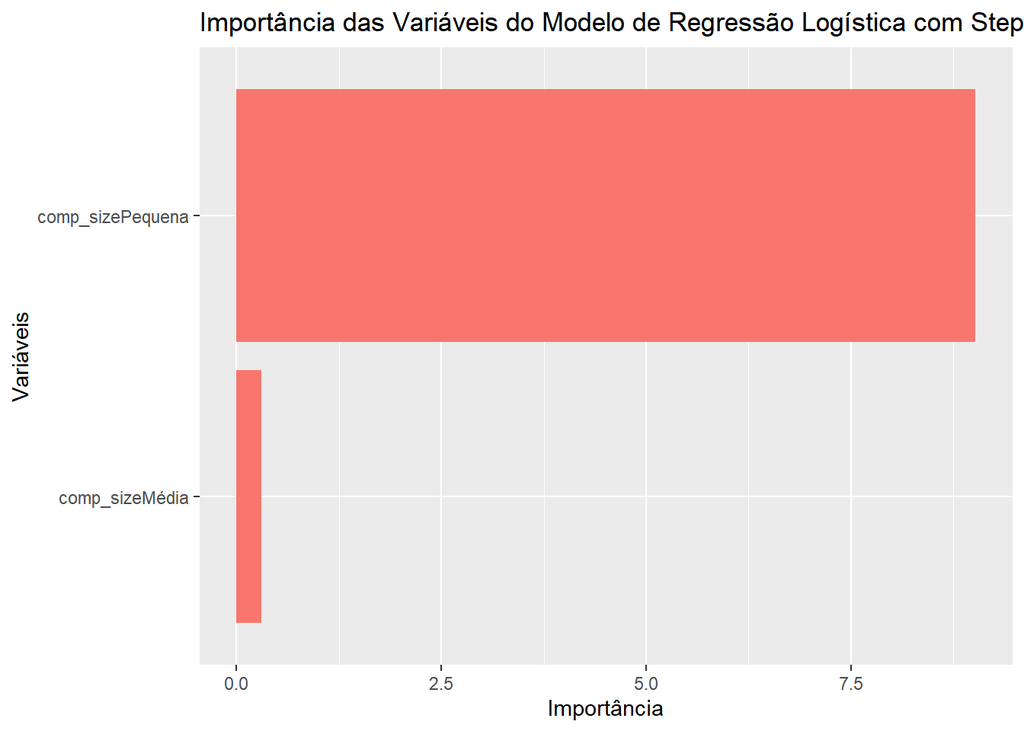

```r
vip(log_stepwise, mapping = aes(fill = Sign)) +
  labs(title = "Importância das Variáveis do Modelo de Regressão Logística com Stepwise", x = "Variáveis", y = "Importância")
```

### Regressão Logística sem Outliers

Durante o processo para estimar o modelo de regressão logística, foi feito um alerta que pode ser resultado no número elevado de outliers do dataset, conforme já apontado acima. Assim, vamos estimar o modelo de regressão logítica sem os outliers, utilizando o método de critério IQR (Intervalo Interquartil) para ver se o desempenho dos modelos melhoram.

Nesse caso, o primeiro caso é eliminar os outliers. Como os outliers estão concentrados no limite superior da coluna ‘sales’, vamos excluir somente esses valores.

```r
Q1 <- quantile(dados$sales_x, 0.25)
Q3 <- quantile(dados$sales_x, 0.75)
IQR <- Q3 - Q1

ls <- Q3 + 1.5 * IQR

dados_sem_outliers <- subset(dados, sales_x <= ls)
```

A etapa seguinte é criar os datasets de treinamento e teste, onde 80% do dataset será de treinamento:

```r
idx_sem_outliers <- sample(nrow(dados_sem_outliers), size = .80 * nrow(dados_sem_outliers), replace = FALSE)

treino_sem_outliers <- dados_sem_outliers[idx_sem_outliers,]
#teste_sem_outliers  <- dados_sem_outliers[-idx_sem_outliers,]
```

O primeiro modelo a ser estimado é o de regressão logística:

```r
log_sem_outliers <- glm(will_close ~ ., data = treino_sem_outliers, family = 'binomial')
```

```
## Warning: glm.fit: probabilidades ajustadas numericamente 0 ou 1 ocorreu
```

```r
summary(log_sem_outliers)
```

```
##
## Call:
## glm(formula = will_close ~ ., family = "binomial", data = treino_sem_outliers)
##
## Coefficients:
##                     Estimate Std. Error z value Pr(>|z|)
## (Intercept)       -3.250e+00  4.396e-01  -7.394 1.43e-13 ***
## amort              4.397e-07  1.065e-06   0.413  0.67978
## curr_assets       -2.824e-07  2.936e-07  -0.962  0.33611
## curr_liab          1.108e-07  1.551e-07   0.714  0.47493
## extra_exp         -2.775e-04  2.744e-04  -1.011  0.31181
## extra_inc          2.755e-04  2.743e-04   1.004  0.31530
## extra_profit_loss -2.749e-04  2.743e-04  -1.002  0.31628
## fixed_assets      -2.411e-06  2.382e-06  -1.012  0.31148
## inc_bef_tax        2.012e-08  5.139e-07   0.039  0.96877
## intang_assets      2.396e-06  2.389e-06   1.003  0.31597
## inventories        2.044e-07  2.838e-07   0.720  0.47132
## liq_assets         5.150e-07  3.337e-07   1.543  0.12282
## material_exp       2.256e-08  4.985e-08   0.453  0.65090
## personnel_exp      1.450e-07  3.176e-07   0.457  0.64794
## profit_loss_year  -6.446e-08  7.743e-07  -0.083  0.93365
## sales_x           -7.875e-06  2.434e-06  -3.236  0.00121 **
## share_eq           5.900e-08  1.671e-07   0.353  0.72407
## subscribed_cap    -6.158e-08  1.397e-07  -0.441  0.65941
## tang_assets        2.271e-06  2.380e-06   0.954  0.33984
## urban_m            1.060e-01  6.523e-02   1.625  0.10416
## region_mEast      -3.339e-01  1.364e-01  -2.448  0.01436 *
## region_mWest      -2.605e-01  1.576e-01  -1.653  0.09831 .
## labor_avg         -2.019e-02  4.079e-02  -0.495  0.62053
## curr_idx_liq      -2.854e-06  8.592e-06  -0.332  0.73975
## comp_age           6.438e-03  7.185e-03   0.896  0.37023
## comp_sizeMédia    -6.577e-01  3.166e-01  -2.078  0.03776 *
## comp_sizePequena   4.922e-02  3.788e-01   0.130  0.89662
## ---
## Signif. codes:  0 '***' 0.001 '**' 0.01 '*' 0.05 '.' 0.1 ' ' 1
##
## (Dispersion parameter for binomial family taken to be 1)
##
##     Null deviance: 3741.7  on 14665  degrees of freedom
## Residual deviance: 3611.0  on 14639  degrees of freedom
## AIC: 3665
##
## Number of Fisher Scoring iterations: 11
```

Agora, vamos aplicar o modelo de previsão nos dados de teste para estimar as probabilidades:

```r
prob_log_sem_outliers <- predict(log_sem_outliers, newdata = teste, type = "response")
```

E armazenar em um tibble os resultados das probabilidades obtidas pela regressão logística e a respectiva classe observada:

```r
desempenho <- desempenho %>%
  bind_rows(tibble(prob = prob_log_sem_outliers,
                   classes = teste$will_close,
                   metodo = "logística sem outliers"))
```

Abaixo, foi plotado o gráfico com a importância de cada variável para esse modelo:

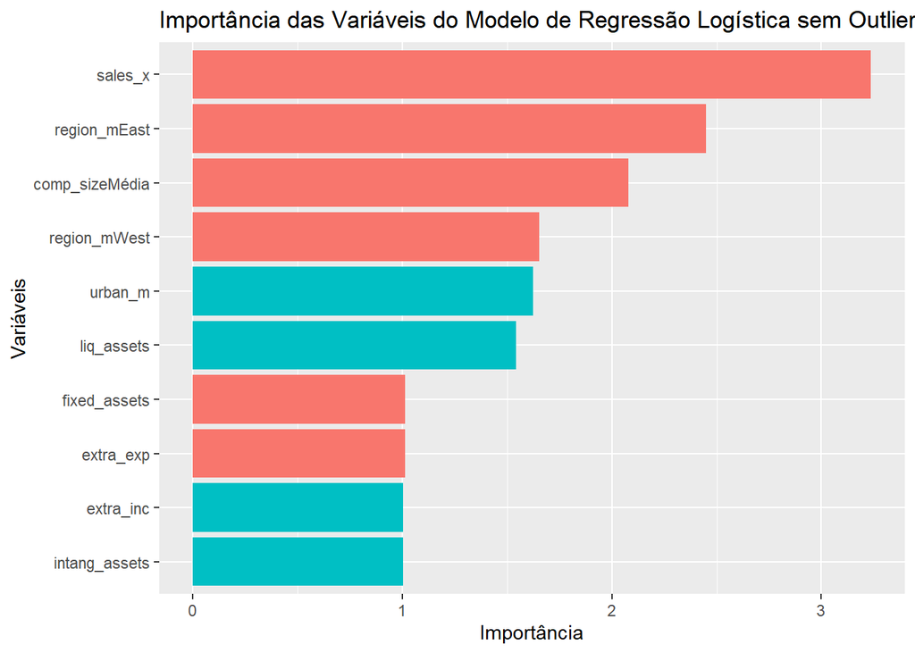

```r
vip(log_sem_outliers, mapping = aes(fill = Sign)) +
  labs(title = "Importância das Variáveis do Modelo de Regressão Logística sem Outliers", x = "Variáveis", y = "Importância")
```

### Modelo Ridge sem Outliers

O próximo modelo a ser estimado sem os outliers é o Ridge. Assim como foi feito no modelo ridge anterior, deverão ser preparadados os datasets de treinamento e teste para aplicação da função do pacote glmnet.

```r
X_treino_sem_outliers <- model.matrix(will_close ~ ., dados_sem_outliers)[idx_sem_outliers,-1]
y_treino_sem_outliers <- dados_sem_outliers$will_close[idx_sem_outliers]

#X_teste_sem_outliers <- model.matrix(will_close ~ ., dados_sem_outliers)[-idx_sem_outliers,-1]
#y_teste_sem_outliers <- dados_sem_outliers$will_close[-idx_sem_outliers]
```

Abaixo, foi criado o modelo Ridge e plotando o gráfico com os lambdas variando até 500:

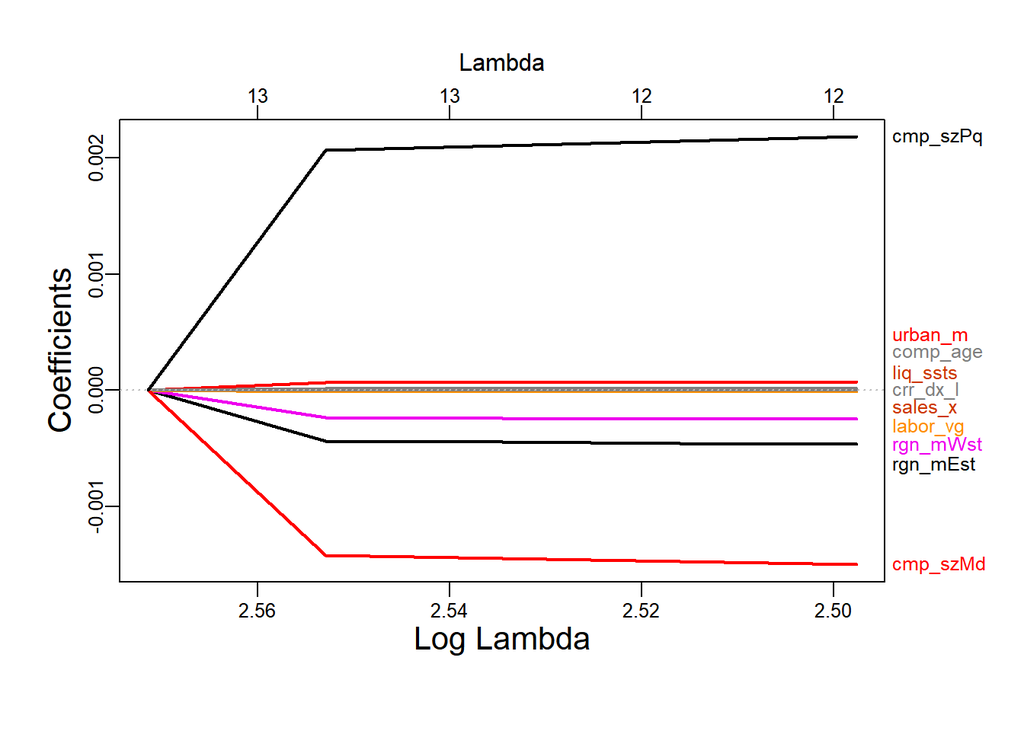

```r
ridge_sem_outliers <- glmnet(X_treino_sem_outliers, y_treino_sem_outliers,  alpha = 0,
                             nlambda = 500, family = "binomial")
plot_glmnet(ridge_sem_outliers, lwd = 2, cex.lab = 1.3)
```

A seguir, vamos fazer a validação cruzada do modelo:

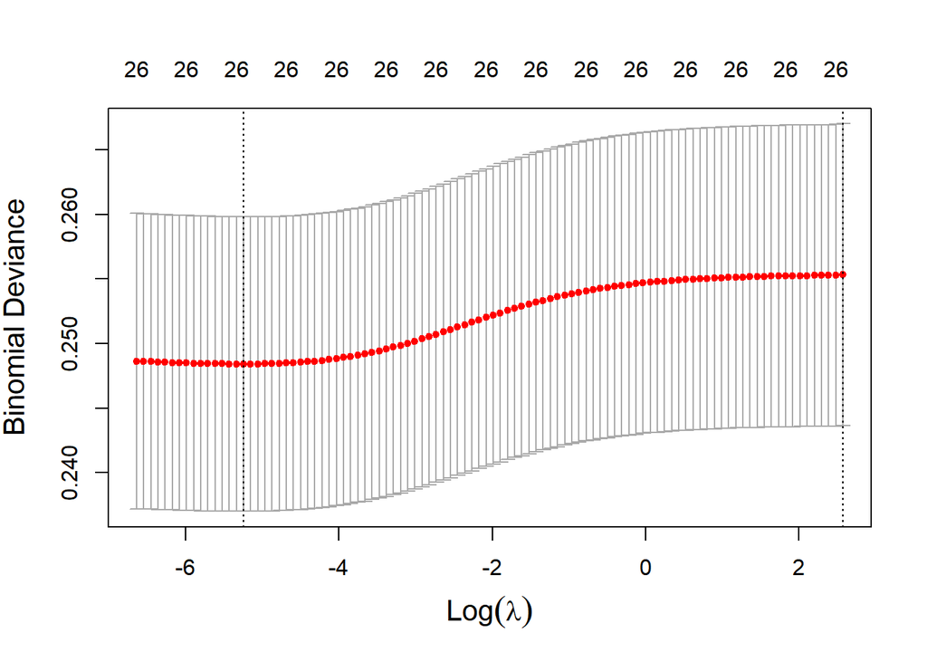

```r
cv_ridge_sem_outliers <- cv.glmnet(X_treino_sem_outliers, y_treino_sem_outliers, alpha = 0, family = "binomial")
plot(cv_ridge_sem_outliers, cex.lab = 1.3)
```

Vamos aplicar o modelo de previsão com base no melhor lambda (menor erro), estimando as probabilidades a partir da base de teste:

```r
prob_ridge_sem_outliers <- predict(ridge_sem_outliers, newx = X_teste,
                      s = cv_ridge_sem_outliers$lambda.min, type = "response")
```

E armazenar em um tibble os resultados das probabilidades obtidas pelo modelo Ridge e a respectiva classe observada:

```r
desempenho <- desempenho %>%
  bind_rows(tibble(prob = as.numeric(prob_ridge_sem_outliers),
                   classes = y_teste,
                   metodo = "ridge sem outliers"))
```

Abaixo, plotamos o gráfico com a importância de cada variável para esse modelo Rigde:

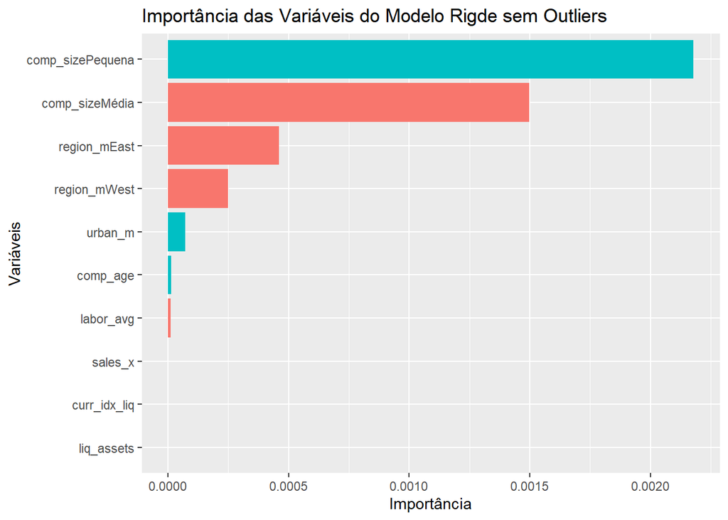

```r
vip(ridge_sem_outliers, mapping = aes(fill = Sign)) +
  labs(title = "Importância das Variáveis do Modelo Rigde sem Outliers", x = "Variáveis", y = "Importância")
```

### Regressão LASSO sem Outliers

O modelo seguinte a ser criado sem outliers é o LASSO. Assim como no modelo Ridge, foi criado o modelo LASSO e plotado o gráfico com os lambdas variando até 500:

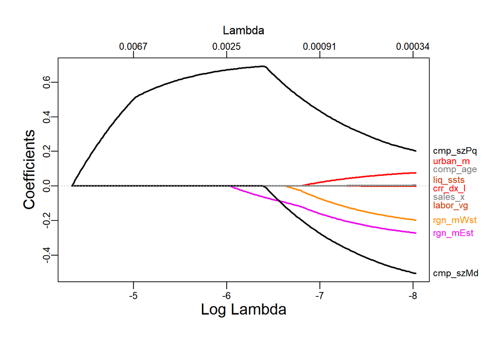

```r
lasso_sem_outliers <- glmnet(X_treino_sem_outliers, y_treino_sem_outliers,
                             alpha = 1, nlambda = 500, family = "binomial")
plot_glmnet(lasso_sem_outliers, lwd = 2, cex.lab = 1.3)
```

O próximo passo é fazer a validação cruzada do modelo:

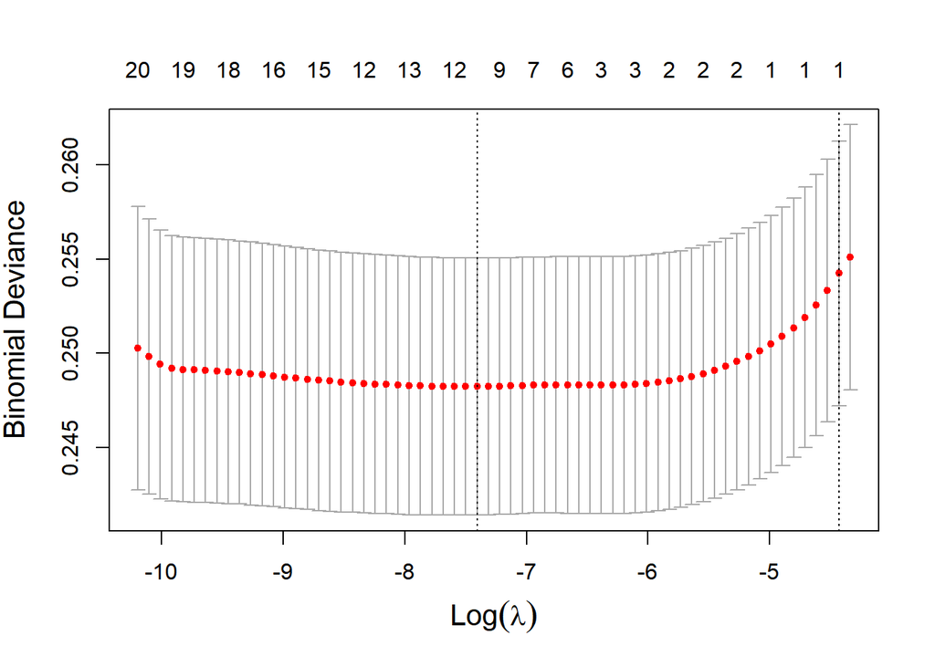

```r
cv_lasso_sem_outliers <- cv.glmnet(X_treino_sem_outliers, y_treino_sem_outliers, alpha = 1, family = "binomial")
plot(cv_lasso_sem_outliers, cex.lab = 1.3)
```

Agora, será aplicado o modelo de previsão com base no melhor lambda (menor erro), estimando as probabilidades a partir da base de teste:

```r
prob_lasso_sem_outliers <- predict(lasso_sem_outliers, newx = X_teste,
                                   s = cv_lasso_sem_outliers$lambda.min, type = "response")
```

E armazenado em um tibble os resultados das probabilidades obtidas pelo modelo Lasso e a respectiva classe observada:

```r
desempenho <- desempenho %>%
  bind_rows(tibble(prob = as.numeric(prob_lasso_sem_outliers),
                   classes = y_teste,
                   metodo = "lasso sem outliers"))
```

Abaixo, foi plotado o gráfico com a importância de cada variável para esse modelo:

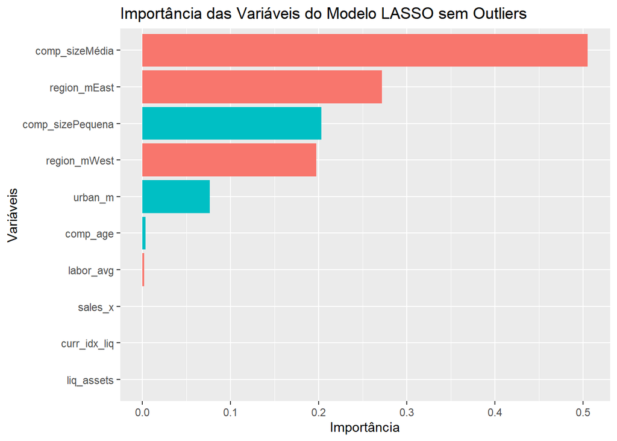

```r
vip(lasso_sem_outliers, mapping = aes(fill = Sign)) +
  labs(title = "Importância das Variáveis do Modelo LASSO sem Outliers", x = "Variáveis", y = "Importância")
```

### Floresta Aleatória sem Outliers

O próximo modelo sem outliers que será criado e testado é o de floresta aleatória com 500 árvores e com todas as variáveis:

```r
rf_sem_outliers <- ranger(will_close ~ ., probability = TRUE, data = treino_sem_outliers)
```

Para essa floresta aleatória com 500 árvores e com todas as variáveis, vamos fazer a previsão a partir dos dados de teste:

```r
prob_rf_sem_outliers <- predict(rf_sem_outliers, teste)$predictions[,2]
```

E armazenando em um tibble os resultados das probabilidades obtidas pelo modelo de floresta aleatória e a respectiva classe observada:

```r
desempenho <- desempenho %>%
  bind_rows(tibble(prob = prob_rf_sem_outliers,
                   classes = teste$will_close,
                   metodo = "floresta aleatória sem outliers"))
```

Abaixo, plotamos o gráfico com a importância de cada variável para esse modelo de floresta aleatória:

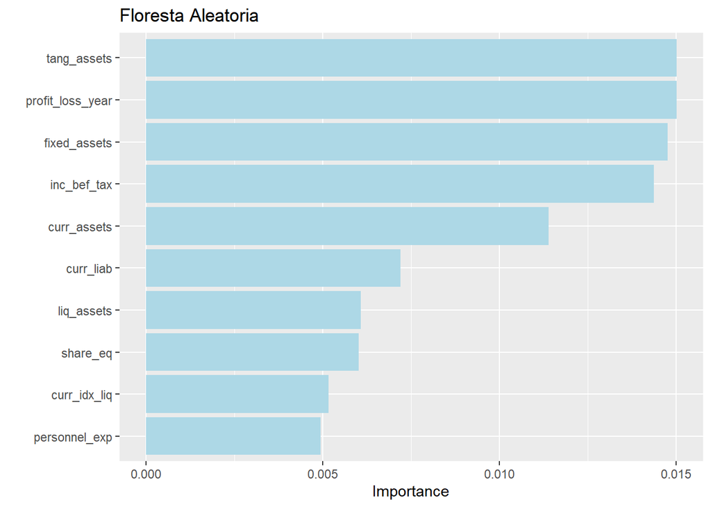

```r
vip(ranger(will_close ~ ., probability = TRUE, importance = "permutation", data = dados_sem_outliers), aesthetics = list(fill = "lightblue")) + labs(title = "Floresta Aleatoria")
```

Agora, vamos iterar para testar o número de árvores de 1 a 500, bem como o número de variáveis por split, plotar o resultado dessa iteração:

```r
result_arvores_sem_outliers <- crossing(mtry = c(2, 4, 8, 12, 16, 20, 23), #número de variáveis por split a ser testados
                       n_arvores = c(1:10, seq(10, 500, 10)))

itera_sem_outliers <- function(mtry, n_arvores) {
  rf_itera_sem_outliers <- ranger(will_close ~ ., probability = TRUE, num.trees = n_arvores, mtry = mtry, data = treino_sem_outliers)
  return(rf_itera_sem_outliers$prediction.error)
}
result_arvores_sem_outliers <- result_arvores_sem_outliers %>%
  mutate(erro = map2_dbl(mtry, n_arvores, itera_sem_outliers))
head(result_arvores_sem_outliers)
```

```
## # A tibble: 6 × 3
##    mtry n_arvores   erro
##   <dbl>     <dbl>  <dbl>
## 1     2         1 0.0423
## 2     2         2 0.0441
## 3     2         3 0.0436
## 4     2         4 0.0379
## 5     2         5 0.0392
## 6     2         6 0.0347
```

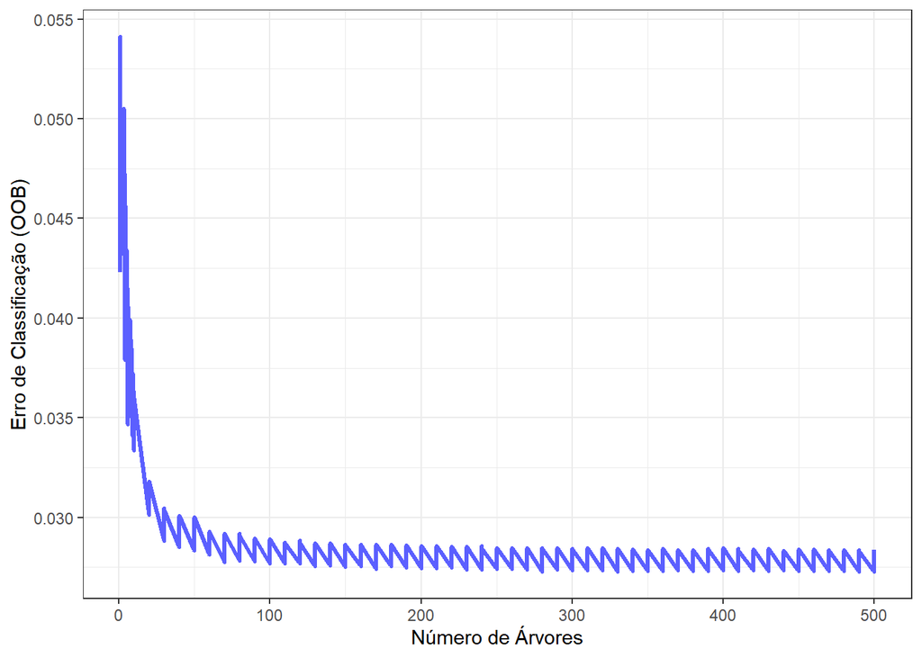

```r
result_arvores_sem_outliers %>% ggplot(aes(n_arvores, erro)) +
 geom_line(color = "#5B5FFF", size = 1.2) +
 labs(x = "Número de Árvores", y = "Erro de Classificação (OOB)") +
 theme_bw()
```

A partir da iteração acima, vamos obter os dados da floresta ótima (número de árvores e número de variáveis por split) com o menor erro:

```r
floresta_otima_sem_outliers <- result_arvores_sem_outliers %>% as_tibble() %>% filter(erro== min(erro))#Obtendo dados da floresta ótima
mtry_otimo_sem_outliers <- floresta_otima_sem_outliers$mtry #numero de arvores para floresta otima
n_arvores_otimo_sem_outliers <- floresta_otima_sem_outliers$n_arvores # variaveis por split
```

E criar o modelo de floresta aleatória ótima:

```r
rf_otima_sem_outliers <- ranger(will_close ~ ., probability = TRUE, num.trees = n_arvores_otimo_sem_outliers,
                   mtry = mtry_otimo_sem_outliers, data = treino_sem_outliers)
```

Para essa floresta aleatória ótima, vamos fazer a previsão a partir dos dados de teste:

```r
prob_rf_otima_sem_outliers <- predict(rf_otima_sem_outliers, teste)$predictions[,2]
```

```r
desempenho <- desempenho %>%
  bind_rows(tibble(prob = prob_rf_otima_sem_outliers,
                   classes = teste$will_close,
                   metodo = "floresta aleatória ótima sem outliers"))
```

Abaixo, plotamos o gráfico com a importância de cada variável para esse modelo de floresta aleatória otimizada:

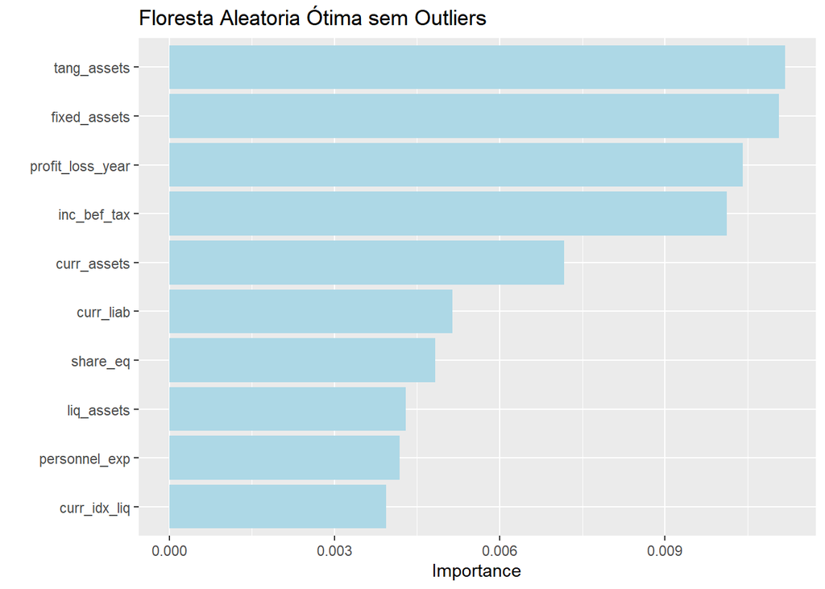

```r
vip(ranger(will_close ~ ., probability = TRUE, importance = "permutation", num.trees = n_arvores_otimo_sem_outliers, mtry = mtry_otimo_sem_outliers, data = treino_sem_outliers),
    aesthetics = list(fill = "lightblue")) + labs(title = "Floresta Aleatoria Ótima sem Outliers")
```

### Boosting sem outliers

Agora, será criado e testado nesse ciclo de modelagem é o Boosting com 500 árvores e taxa de aprendizagem 0,05 sem os outliers:

```r
(fit_bst_sem_outliers <- gbm(will_close ~ ., distribution = "bernoulli", n.trees = 500,
                interaction.depth = 4, shrinkage = 0.05, data = treino_sem_outliers))
```

```
## gbm(formula = will_close ~ ., distribution = "bernoulli", data = treino_sem_outliers,
##     n.trees = 500, interaction.depth = 4, shrinkage = 0.05)
## A gradient boosted model with bernoulli loss function.
## 500 iterations were performed.
## There were 24 predictors of which 23 had non-zero influence.
```

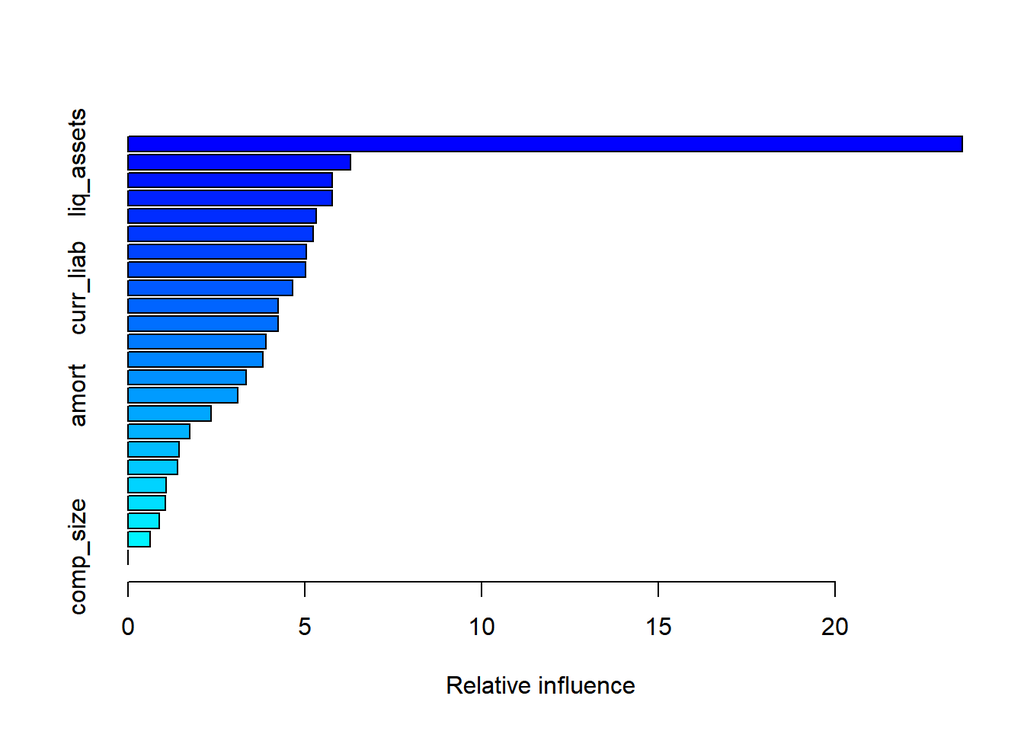

```
##                                 var    rel.inf
## sales_x                     sales_x 23.6069742
## liq_assets               liq_assets  6.2985446
## curr_assets             curr_assets  5.7906774
## share_eq                   share_eq  5.7760039
## personnel_exp         personnel_exp  5.3214844
## curr_idx_liq           curr_idx_liq  5.2497385
## labor_avg                 labor_avg  5.0503298
## inventories             inventories  5.0202364
## curr_liab                 curr_liab  4.6487768
## fixed_assets           fixed_assets  4.2442199
## inc_bef_tax             inc_bef_tax  4.2431508
## material_exp           material_exp  3.9101483
## profit_loss_year   profit_loss_year  3.8178075
## comp_age                   comp_age  3.3407256
## amort                         amort  3.1134219
## subscribed_cap       subscribed_cap  2.3420391
## extra_profit_loss extra_profit_loss  1.7579519
## tang_assets             tang_assets  1.4402185
## intang_assets         intang_assets  1.3986761
## extra_inc                 extra_inc  1.0797890
## urban_m                     urban_m  1.0499401
## extra_exp                 extra_exp  0.8762191
## region_m                   region_m  0.6229261
## comp_size                 comp_size  0.0000000
```

```r
summary(fit_bst_sem_outliers)
```

O passo seguinte é fazer a validação cruzadas do modelo para obter o número de árvores ótimo:

```r
fit_cv_sem_outliers <- gbm(will_close ~ ., data = treino_sem_outliers, cv.folds = 5, n.trees = 500,
              interaction.depth = 4, distribution = "bernoulli", shrinkage = 0.05)

num_arv_boost_sem_outliers <- gbm.perf(fit_cv_sem_outliers, method = "cv") #obtendo a árvore ótima
```

[figure not shown]

Aplicando o modelo de previsão com base na melhor quantidade de árvores (menor erro) e estimando as probabilidades a partir da base de teste, temos:

```r
prob_gbm_sem_outliers <- predict(fit_cv_sem_outliers, teste, n.trees = num_arv_boost_sem_outliers, type = "response")
```

```r
desempenho <- desempenho %>%
  bind_rows(tibble(prob = prob_gbm_sem_outliers,
                   classes = teste$will_close,
                   metodo = "boosting sem outliers"))
```

### Análise dos Modelos Estimados

Vamos plotar a curva ROC:

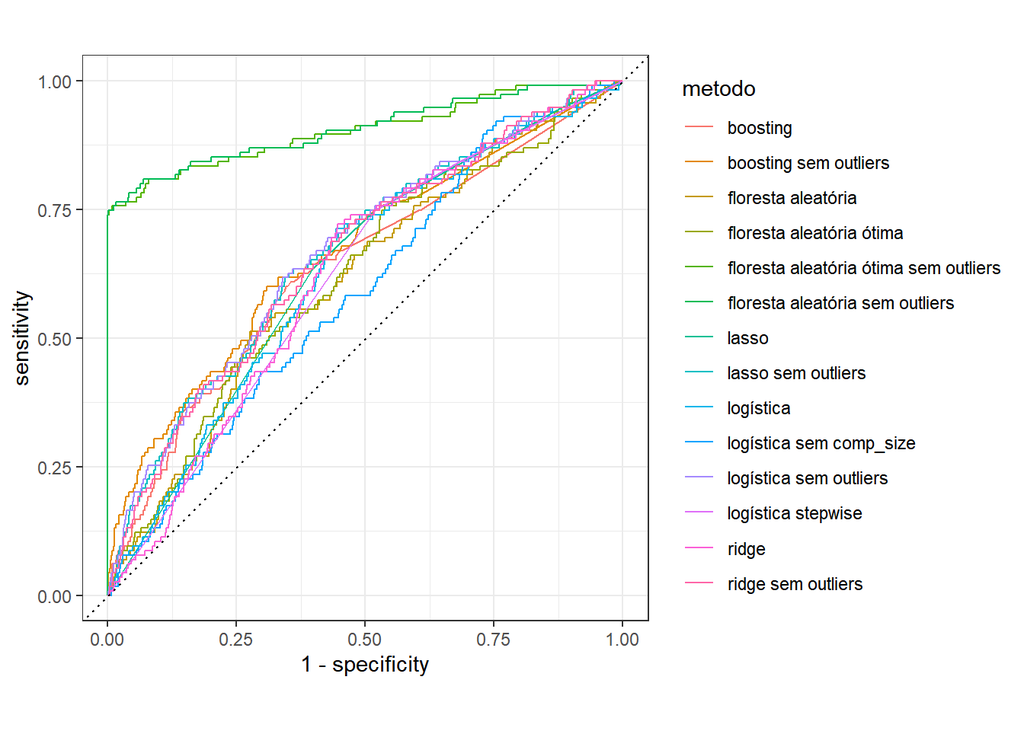

```r
desempenho %>%
  mutate(classes = factor(classes)) %>%
  group_by(metodo) %>%
  roc_curve(classes, prob, event_level = "second") %>%
  autoplot()
```

Vamos analisar AUC para cada modelo estimado:

```r
desempenho %>%
  mutate(classes = factor(classes)) %>%
  group_by(metodo) %>%
  roc_auc(classes, prob, event_level = "second") %>%
  arrange(desc(.estimate))
```

```
## # A tibble: 14 × 4
##    metodo                                .metric .estimator .estimate
##    <chr>                                 <chr>   <chr>          <dbl>
##  1 floresta aleatória sem outliers       roc_auc binary         0.907
##  2 floresta aleatória ótima sem outliers roc_auc binary         0.904
##  3 logística sem outliers                roc_auc binary         0.669
##  4 boosting sem outliers                 roc_auc binary         0.667
##  5 lasso sem outliers                    roc_auc binary         0.666
##  6 ridge sem outliers                    roc_auc binary         0.660
##  7 boosting                              roc_auc binary         0.638
##  8 lasso                                 roc_auc binary         0.633
##  9 logística                             roc_auc binary         0.628
## 10 ridge                                 roc_auc binary         0.622
## 11 floresta aleatória ótima              roc_auc binary         0.620
## 12 logística stepwise                    roc_auc binary         0.617
## 13 floresta aleatória                    roc_auc binary         0.614
## 14 logística sem comp_size               roc_auc binary         0.589
```